# Intertwining of the Igf system and animal welfare

Linear mixed models

Author

Anja Eggert, Anne-Marie Galow, et al.

Published

January 23, 2026

# R Libraries

```r
library(tidyverse)     # tidy universe
library(kableExtra)    # html-table
library(patchwork)     # combine plots
library(lmerTest)      # mixed model
library(car)           # ANOVA
library(emmeans)       # post-hoc
library(performance)   # model performance
library(Hmisc)         # Computes correlation and p-value matrix
library(viridis)       # colour scale
```

```r
set.seed(1989)
```

# Data

## Read data

Data processing done in file “igf-biomarker-summary-stats.qmd”.

```r
load("./data/data-processed.RData")
```

# Correlations of parameters

## All pairwise correlations

```r
dat.cor.all <- dat.w |>
  dplyr::select(where(is.numeric))
```

Calculate correlations and p values:

```r
cor.all <- rcorr(as.matrix(dat.cor.all))

cor.all_matrix  <- round(cor.all$r, 2)
pval.all_matrix <- round(cor.all$P, 3)
```

```r
cor.all_matrix |>
  kable(caption = "Person correlation coefficients") |>
  kable_styling(bootstrap_options = c("striped", "hover"),
                font_size = 12) |>
  scroll_box()
```

Person correlation coefficients

|  | insem.age | total.piglets | prop.males | prop.stillborn | prop.spreizer | prop.lbw | mean.bodyweight | cort.ser.105dpc | cort.ser.8dpp | cort.sal.105dpc | cort.sal.8dpp | bioact.ser.30dpc | bioact.ser.105dpc | bioact.ser.8dpp | igf2.ser.105dpc | igf2.ser.8dpp | igf1.ser.105dpc | igf1.ser.8dpp | igfbp2.ser.105dpc | igfbp2.ser.8dpp | igfbp3.ser.105dpc | igfbp3.ser.8dpp | proteolysis.105dpc | proteolysis.8dpp | stc1.105dpc | stc1.8dpp | calc.30dpc | calc.105dpc | calc.8dpp | … |
| --- | --- | --- | --- | --- | --- | --- | --- | --- | --- | --- | --- | --- | --- | --- | --- | --- | --- | --- | --- | --- | --- | --- | --- | --- | --- | --- | --- | --- | --- | --- |
| insem.age | 1.00 | 0.35 | -0.06 | 0.25 | -0.21 | -0.20 | 0.16 | -0.19 | -0.44 | 0.02 | -0.19 | -0.31 | -0.08 | -0.07 | 0.07 | -0.28 | 0.53 | 0.42 | 0.18 | 0.32 | -0.15 | -0.10 | 0.19 | 0.13 | 0.15 | 0.10 | -0.10 | 0.00 | 0.01 | … |
| total.piglets | 0.35 | 1.00 | 0.19 | 0.33 | 0.31 | 0.29 | -0.40 | 0.09 | -0.02 | 0.23 | -0.01 | 0.23 | 0.09 | 0.28 | -0.14 | -0.40 | -0.05 | -0.04 | 0.14 | 0.12 | -0.23 | -0.11 | 0.17 | -0.30 | -0.26 | -0.30 | 0.20 | 0.32 | 0.15 | … |
| prop.males | -0.06 | 0.19 | 1.00 | 0.09 | 0.07 | 0.21 | -0.21 | 0.24 | 0.49 | -0.09 | -0.11 | 0.17 | 0.10 | 0.01 | 0.20 | 0.18 | -0.16 | -0.21 | 0.04 | 0.18 | 0.25 | 0.29 | 0.08 | -0.04 | -0.23 | -0.22 | 0.06 | 0.07 | -0.05 | … |
| prop.stillborn | 0.25 | 0.33 | 0.09 | 1.00 | -0.10 | -0.11 | 0.00 | -0.09 | 0.43 | -0.06 | 0.33 | -0.16 | 0.15 | 0.00 | 0.06 | -0.15 | -0.19 | -0.28 | 0.08 | 0.24 | 0.01 | 0.09 | 0.37 | 0.17 | -0.38 | -0.40 | -0.05 | 0.09 | 0.00 | … |
| prop.spreizer | -0.21 | 0.31 | 0.07 | -0.10 | 1.00 | 0.27 | -0.25 | 0.05 | -0.10 | 0.12 | 0.05 | 0.25 | 0.01 | -0.07 | 0.09 | -0.24 | -0.05 | -0.04 | 0.20 | 0.09 | -0.11 | 0.05 | -0.16 | -0.16 | -0.44 | -0.39 | 0.30 | 0.32 | -0.15 | … |
| prop.lbw | -0.20 | 0.29 | 0.21 | -0.11 | 0.27 | 1.00 | -0.88 | -0.11 | -0.18 | 0.43 | -0.05 | 0.23 | -0.05 | 0.05 | 0.37 | 0.28 | -0.04 | 0.28 | 0.14 | -0.12 | 0.27 | -0.03 | 0.15 | -0.42 | -0.01 | -0.06 | -0.07 | -0.03 | -0.34 | … |
| mean.bodyweight | 0.16 | -0.40 | -0.21 | 0.00 | -0.25 | -0.88 | 1.00 | -0.13 | 0.01 | -0.42 | -0.04 | -0.31 | -0.11 | -0.13 | -0.40 | -0.30 | -0.05 | -0.27 | -0.14 | 0.08 | -0.13 | 0.11 | -0.25 | 0.53 | 0.00 | 0.06 | 0.04 | -0.03 | 0.28 | … |
| cort.ser.105dpc | -0.19 | 0.09 | 0.24 | -0.09 | 0.05 | -0.11 | -0.13 | 1.00 | 0.49 | 0.31 | -0.13 | 0.32 | 0.44 | -0.08 | 0.26 | -0.15 | 0.23 | 0.13 | 0.14 | 0.35 | 0.07 | 0.15 | -0.34 | 0.20 | 0.06 | -0.06 | 0.23 | 0.54 | 0.24 | … |
| cort.ser.8dpp | -0.44 | -0.02 | 0.49 | 0.43 | -0.10 | -0.18 | 0.01 | 0.49 | 1.00 | -0.22 | 0.02 | 0.12 | 0.24 | -0.25 | 0.11 | 0.09 | -0.09 | -0.16 | 0.11 | 0.40 | 0.35 | 0.23 | 0.02 | 0.33 | -0.08 | -0.10 | -0.25 | 0.06 | -0.08 | … |
| cort.sal.105dpc | 0.02 | 0.23 | -0.09 | -0.06 | 0.12 | 0.43 | -0.42 | 0.31 | -0.22 | 1.00 | -0.33 | 0.26 | 0.16 | 0.25 | 0.40 | -0.29 | 0.33 | 0.43 | 0.03 | 0.13 | -0.27 | -0.08 | 0.35 | -0.30 | 0.09 | -0.10 | 0.32 | 0.24 | 0.16 | … |
| cort.sal.8dpp | -0.19 | -0.01 | -0.11 | 0.33 | 0.05 | -0.05 | -0.04 | -0.13 | 0.02 | -0.33 | 1.00 | -0.11 | 0.01 | -0.06 | -0.15 | 0.35 | -0.03 | -0.21 | -0.19 | -0.48 | 0.29 | 0.08 | -0.49 | 0.40 | 0.04 | 0.13 | 0.04 | -0.02 | -0.05 | … |
| bioact.ser.30dpc | -0.31 | 0.23 | 0.17 | -0.16 | 0.25 | 0.23 | -0.31 | 0.32 | 0.12 | 0.26 | -0.11 | 1.00 | 0.54 | 0.46 | 0.04 | -0.18 | 0.00 | -0.28 | -0.02 | -0.13 | -0.26 | -0.23 | -0.34 | -0.20 | -0.10 | -0.12 | 0.18 | 0.22 | 0.31 | … |
| bioact.ser.105dpc | -0.08 | 0.09 | 0.10 | 0.15 | 0.01 | -0.05 | -0.11 | 0.44 | 0.24 | 0.16 | 0.01 | 0.54 | 1.00 | 0.63 | 0.51 | -0.20 | 0.36 | 0.05 | 0.18 | -0.09 | -0.17 | -0.25 | -0.30 | 0.21 | -0.21 | -0.23 | 0.20 | 0.18 | 0.21 | … |
| bioact.ser.8dpp | -0.07 | 0.28 | 0.01 | 0.00 | -0.07 | 0.05 | -0.13 | -0.08 | -0.25 | 0.25 | -0.06 | 0.46 | 0.63 | 1.00 | 0.08 | -0.28 | 0.42 | 0.11 | 0.11 | -0.13 | -0.34 | -0.44 | -0.15 | -0.27 | -0.03 | -0.08 | 0.20 | 0.01 | 0.27 | … |
| igf2.ser.105dpc | 0.07 | -0.14 | 0.20 | 0.06 | 0.09 | 0.37 | -0.40 | 0.26 | 0.11 | 0.40 | -0.15 | 0.04 | 0.51 | 0.08 | 1.00 | 0.13 | 0.38 | 0.47 | 0.50 | 0.31 | 0.01 | -0.16 | 0.23 | -0.07 | -0.13 | -0.23 | -0.16 | -0.14 | -0.43 | … |
| igf2.ser.8dpp | -0.28 | -0.40 | 0.18 | -0.15 | -0.24 | 0.28 | -0.30 | -0.15 | 0.09 | -0.29 | 0.35 | -0.18 | -0.20 | -0.28 | 0.13 | 1.00 | -0.10 | 0.03 | -0.11 | -0.15 | 0.35 | 0.27 | 0.00 | -0.24 | 0.53 | 0.64 | -0.21 | -0.21 | -0.17 | … |
| igf1.ser.105dpc | 0.53 | -0.05 | -0.16 | -0.19 | -0.05 | -0.04 | -0.05 | 0.23 | -0.09 | 0.33 | -0.03 | 0.00 | 0.36 | 0.42 | 0.38 | -0.10 | 1.00 | 0.66 | 0.09 | 0.14 | -0.36 | -0.58 | -0.37 | -0.29 | 0.28 | 0.15 | 0.06 | -0.02 | -0.23 | … |
| igf1.ser.8dpp | 0.42 | -0.04 | -0.21 | -0.28 | -0.04 | 0.28 | -0.27 | 0.13 | -0.16 | 0.43 | -0.21 | -0.28 | 0.05 | 0.11 | 0.47 | 0.03 | 0.66 | 1.00 | 0.01 | -0.04 | -0.08 | -0.30 | -0.23 | -0.35 | 0.39 | 0.22 | 0.06 | -0.13 | -0.35 | … |
| igfbp2.ser.105dpc | 0.18 | 0.14 | 0.04 | 0.08 | 0.20 | 0.14 | -0.14 | 0.14 | 0.11 | 0.03 | -0.19 | -0.02 | 0.18 | 0.11 | 0.50 | -0.11 | 0.09 | 0.01 | 1.00 | 0.68 | 0.27 | 0.15 | 0.10 | -0.26 | -0.43 | -0.46 | -0.16 | -0.05 | -0.27 | … |
| igfbp2.ser.8dpp | 0.32 | 0.12 | 0.18 | 0.24 | 0.09 | -0.12 | 0.08 | 0.35 | 0.40 | 0.13 | -0.48 | -0.13 | -0.09 | -0.13 | 0.31 | -0.15 | 0.14 | -0.04 | 0.68 | 1.00 | 0.05 | 0.22 | 0.38 | -0.23 | -0.33 | -0.36 | -0.21 | -0.07 | -0.30 | … |
| igfbp3.ser.105dpc | -0.15 | -0.23 | 0.25 | 0.01 | -0.11 | 0.27 | -0.13 | 0.07 | 0.35 | -0.27 | 0.29 | -0.26 | -0.17 | -0.34 | 0.01 | 0.35 | -0.36 | -0.08 | 0.27 | 0.05 | 1.00 | 0.72 | -0.27 | 0.24 | -0.06 | -0.03 | -0.13 | -0.01 | -0.12 | … |
| igfbp3.ser.8dpp | -0.10 | -0.11 | 0.29 | 0.09 | 0.05 | -0.03 | 0.11 | 0.15 | 0.23 | -0.08 | 0.08 | -0.23 | -0.25 | -0.44 | -0.16 | 0.27 | -0.58 | -0.30 | 0.15 | 0.22 | 0.72 | 1.00 | -0.09 | 0.43 | -0.09 | -0.02 | 0.16 | 0.20 | 0.05 | … |
| proteolysis.105dpc | 0.19 | 0.17 | 0.08 | 0.37 | -0.16 | 0.15 | -0.25 | -0.34 | 0.02 | 0.35 | -0.49 | -0.34 | -0.30 | -0.15 | 0.23 | 0.00 | -0.37 | -0.23 | 0.10 | 0.38 | -0.27 | -0.09 | 1.00 | -0.30 | -0.25 | -0.28 | -0.31 | -0.02 | -0.08 | … |
| proteolysis.8dpp | 0.13 | -0.30 | -0.04 | 0.17 | -0.16 | -0.42 | 0.53 | 0.20 | 0.33 | -0.30 | 0.40 | -0.20 | 0.21 | -0.27 | -0.07 | -0.24 | -0.29 | -0.35 | -0.26 | -0.23 | 0.24 | 0.43 | -0.30 | 1.00 | -0.07 | -0.05 | 0.15 | 0.08 | 0.25 | … |
| stc1.105dpc | 0.15 | -0.26 | -0.23 | -0.38 | -0.44 | -0.01 | 0.00 | 0.06 | -0.08 | 0.09 | 0.04 | -0.10 | -0.21 | -0.03 | -0.13 | 0.53 | 0.28 | 0.39 | -0.43 | -0.33 | -0.06 | -0.09 | -0.25 | -0.07 | 1.00 | 0.95 | -0.01 | -0.16 | 0.14 | … |
| stc1.8dpp | 0.10 | -0.30 | -0.22 | -0.40 | -0.39 | -0.06 | 0.06 | -0.06 | -0.10 | -0.10 | 0.13 | -0.12 | -0.23 | -0.08 | -0.23 | 0.64 | 0.15 | 0.22 | -0.46 | -0.36 | -0.03 | -0.02 | -0.28 | -0.05 | 0.95 | 1.00 | 0.03 | -0.13 | 0.12 | … |
| calc.30dpc | -0.10 | 0.20 | 0.06 | -0.05 | 0.30 | -0.07 | 0.04 | 0.23 | -0.25 | 0.32 | 0.04 | 0.18 | 0.20 | 0.20 | -0.16 | -0.21 | 0.06 | 0.06 | -0.16 | -0.21 | -0.13 | 0.16 | -0.31 | 0.15 | -0.01 | 0.03 | 1.00 | 0.67 | 0.42 | … |
| calc.105dpc | 0.00 | 0.32 | 0.07 | 0.09 | 0.32 | -0.03 | -0.03 | 0.54 | 0.06 | 0.24 | -0.02 | 0.22 | 0.18 | 0.01 | -0.14 | -0.21 | -0.02 | -0.13 | -0.05 | -0.07 | -0.01 | 0.20 | -0.02 | 0.08 | -0.16 | -0.13 | 0.67 | 1.00 | 0.54 | … |
| calc.8dpp | 0.01 | 0.15 | -0.05 | 0.00 | -0.15 | -0.34 | 0.28 | 0.24 | -0.08 | 0.16 | -0.05 | 0.31 | 0.21 | 0.27 | -0.43 | -0.17 | -0.23 | -0.35 | -0.27 | -0.30 | -0.12 | 0.05 | -0.08 | 0.25 | 0.14 | 0.12 | 0.42 | 0.54 | 1.00 | … |
| igfbp23.ser.105dpc | 0.12 | 0.21 | -0.16 | -0.11 | 0.16 | 0.01 | -0.09 | -0.01 | -0.24 | 0.47 | -0.43 | 0.17 | 0.34 | 0.57 | 0.44 | -0.41 | 0.62 | 0.54 | 0.22 | 0.13 | -0.62 | -0.58 | 0.16 | -0.54 | -0.12 | -0.23 | 0.20 | -0.14 | -0.12 | … |
| igfbp23.ser.8dpp | 0.05 | 0.05 | -0.12 | -0.13 | 0.03 | 0.03 | -0.10 | 0.14 | -0.18 | 0.32 | -0.29 | 0.14 | 0.23 | 0.46 | 0.29 | -0.34 | 0.87 | 0.60 | 0.16 | 0.13 | -0.49 | -0.68 | -0.20 | -0.41 | 0.11 | -0.07 | 0.04 | -0.11 | -0.15 | … |

```r
pval.all_matrix |>
  kable(caption = "p values of Person correlation coefficients") |>
  kable_styling(bootstrap_options = c("striped", "hover"),
                font_size = 12) |>
  scroll_box()
```

p values of Person correlation coefficients

|  | insem.age | total.piglets | prop.males | prop.stillborn | prop.spreizer | prop.lbw | mean.bodyweight | cort.ser.105dpc | cort.ser.8dpp | cort.sal.105dpc | cort.sal.8dpp | bioact.ser.30dpc | bioact.ser.105dpc | bioact.ser.8dpp | igf2.ser.105dpc | igf2.ser.8dpp | igf1.ser.105dpc | igf1.ser.8dpp | igfbp2.ser.105dpc | igfbp2.ser.8dpp | igfbp3.ser.105dpc | igfbp3.ser.8dpp | proteolysis.105dpc | proteolysis.8dpp | stc1.105dpc | stc1.8dpp | calc.30dpc | calc.105dpc | calc.8dpp | … |
| --- | --- | --- | --- | --- | --- | --- | --- | --- | --- | --- | --- | --- | --- | --- | --- | --- | --- | --- | --- | --- | --- | --- | --- | --- | --- | --- | --- | --- | --- | --- |
| insem.age | NA | 0.028 | 0.719 | 0.115 | 0.202 | 0.207 | 0.337 | 0.432 | 0.049 | 0.919 | 0.422 | 0.055 | 0.605 | 0.685 | 0.754 | 0.228 | 0.012 | 0.050 | 0.286 | 0.057 | 0.379 | 0.563 | 0.430 | 0.578 | 0.536 | 0.672 | 0.530 | 0.999 | 0.950 | … |
| total.piglets | 0.028 | NA | 0.230 | 0.040 | 0.054 | 0.071 | 0.010 | 0.720 | 0.920 | 0.337 | 0.956 | 0.158 | 0.575 | 0.080 | 0.545 | 0.083 | 0.830 | 0.846 | 0.399 | 0.470 | 0.178 | 0.512 | 0.490 | 0.193 | 0.282 | 0.209 | 0.221 | 0.046 | 0.344 | … |
| prop.males | 0.719 | 0.230 | NA | 0.589 | 0.657 | 0.189 | 0.200 | 0.328 | 0.029 | 0.728 | 0.634 | 0.298 | 0.524 | 0.954 | 0.401 | 0.457 | 0.469 | 0.342 | 0.834 | 0.284 | 0.143 | 0.090 | 0.757 | 0.867 | 0.336 | 0.362 | 0.736 | 0.662 | 0.757 | … |
| prop.stillborn | 0.115 | 0.040 | 0.589 | NA | 0.555 | 0.491 | 0.981 | 0.720 | 0.056 | 0.801 | 0.153 | 0.330 | 0.355 | 0.979 | 0.809 | 0.530 | 0.392 | 0.200 | 0.635 | 0.151 | 0.956 | 0.587 | 0.116 | 0.477 | 0.111 | 0.091 | 0.746 | 0.600 | 0.985 | … |
| prop.spreizer | 0.202 | 0.054 | 0.657 | 0.555 | NA | 0.091 | 0.115 | 0.825 | 0.687 | 0.624 | 0.848 | 0.131 | 0.932 | 0.676 | 0.705 | 0.311 | 0.840 | 0.873 | 0.254 | 0.588 | 0.538 | 0.758 | 0.511 | 0.496 | 0.060 | 0.103 | 0.068 | 0.046 | 0.347 | … |
| prop.lbw | 0.207 | 0.071 | 0.189 | 0.491 | 0.091 | NA | 0.000 | 0.664 | 0.436 | 0.070 | 0.842 | 0.156 | 0.757 | 0.778 | 0.110 | 0.235 | 0.857 | 0.214 | 0.421 | 0.477 | 0.117 | 0.857 | 0.550 | 0.066 | 0.961 | 0.820 | 0.653 | 0.843 | 0.030 | … |
| mean.bodyweight | 0.337 | 0.010 | 0.200 | 0.981 | 0.115 | 0.000 | NA | 0.582 | 0.979 | 0.071 | 0.858 | 0.055 | 0.518 | 0.415 | 0.079 | 0.203 | 0.829 | 0.216 | 0.406 | 0.644 | 0.435 | 0.530 | 0.306 | 0.016 | 0.987 | 0.795 | 0.823 | 0.861 | 0.084 | … |
| cort.ser.105dpc | 0.432 | 0.720 | 0.328 | 0.720 | 0.825 | 0.664 | 0.582 | NA | 0.032 | 0.208 | 0.604 | 0.179 | 0.057 | 0.733 | 0.300 | 0.565 | 0.354 | 0.590 | 0.556 | 0.137 | 0.785 | 0.527 | 0.339 | 0.565 | 0.826 | 0.813 | 0.353 | 0.016 | 0.326 | … |
| cort.ser.8dpp | 0.049 | 0.920 | 0.029 | 0.056 | 0.687 | 0.436 | 0.979 | 0.032 | NA | 0.366 | 0.942 | 0.627 | 0.305 | 0.290 | 0.659 | 0.712 | 0.699 | 0.489 | 0.649 | 0.080 | 0.131 | 0.326 | 0.958 | 0.292 | 0.746 | 0.671 | 0.286 | 0.812 | 0.737 | … |
| cort.sal.105dpc | 0.919 | 0.337 | 0.728 | 0.801 | 0.624 | 0.070 | 0.071 | 0.208 | 0.366 | NA | 0.172 | 0.291 | 0.505 | 0.307 | 0.098 | 0.246 | 0.168 | 0.069 | 0.912 | 0.601 | 0.263 | 0.741 | 0.325 | 0.367 | 0.732 | 0.692 | 0.184 | 0.331 | 0.524 | … |
| cort.sal.8dpp | 0.422 | 0.956 | 0.634 | 0.153 | 0.848 | 0.842 | 0.858 | 0.604 | 0.942 | 0.172 | NA | 0.655 | 0.975 | 0.789 | 0.552 | 0.139 | 0.912 | 0.376 | 0.413 | 0.032 | 0.221 | 0.737 | 0.130 | 0.200 | 0.874 | 0.583 | 0.882 | 0.947 | 0.841 | … |
| bioact.ser.30dpc | 0.055 | 0.158 | 0.298 | 0.330 | 0.131 | 0.156 | 0.055 | 0.179 | 0.627 | 0.291 | 0.655 | NA | 0.000 | 0.003 | 0.882 | 0.458 | 0.995 | 0.202 | 0.887 | 0.451 | 0.125 | 0.194 | 0.152 | 0.396 | 0.686 | 0.619 | 0.264 | 0.178 | 0.054 | … |
| bioact.ser.105dpc | 0.605 | 0.575 | 0.524 | 0.355 | 0.932 | 0.757 | 0.518 | 0.057 | 0.305 | 0.505 | 0.975 | 0.000 | NA | 0.000 | 0.020 | 0.399 | 0.095 | 0.822 | 0.306 | 0.602 | 0.322 | 0.149 | 0.205 | 0.375 | 0.390 | 0.337 | 0.219 | 0.257 | 0.190 | … |
| bioact.ser.8dpp | 0.685 | 0.080 | 0.954 | 0.979 | 0.676 | 0.778 | 0.415 | 0.733 | 0.290 | 0.307 | 0.789 | 0.003 | 0.000 | NA | 0.724 | 0.233 | 0.052 | 0.640 | 0.514 | 0.441 | 0.041 | 0.007 | 0.548 | 0.247 | 0.910 | 0.754 | 0.221 | 0.948 | 0.087 | … |
| igf2.ser.105dpc | 0.754 | 0.545 | 0.401 | 0.809 | 0.705 | 0.110 | 0.079 | 0.300 | 0.659 | 0.098 | 0.552 | 0.882 | 0.020 | 0.724 | NA | 0.574 | 0.102 | 0.037 | 0.026 | 0.178 | 0.966 | 0.501 | 0.471 | 0.820 | 0.596 | 0.361 | 0.499 | 0.569 | 0.060 | … |
| igf2.ser.8dpp | 0.228 | 0.083 | 0.457 | 0.530 | 0.311 | 0.235 | 0.203 | 0.565 | 0.712 | 0.246 | 0.139 | 0.458 | 0.399 | 0.233 | 0.574 | NA | 0.676 | 0.895 | 0.646 | 0.535 | 0.127 | 0.254 | 1.000 | 0.430 | 0.025 | 0.004 | 0.381 | 0.366 | 0.466 | … |
| igf1.ser.105dpc | 0.012 | 0.830 | 0.469 | 0.392 | 0.840 | 0.857 | 0.829 | 0.354 | 0.699 | 0.168 | 0.912 | 0.995 | 0.095 | 0.052 | 0.102 | 0.676 | NA | 0.001 | 0.677 | 0.530 | 0.105 | 0.005 | 0.211 | 0.310 | 0.253 | 0.540 | 0.806 | 0.924 | 0.297 | … |
| igf1.ser.8dpp | 0.050 | 0.846 | 0.342 | 0.200 | 0.873 | 0.214 | 0.216 | 0.590 | 0.489 | 0.069 | 0.376 | 0.202 | 0.822 | 0.640 | 0.037 | 0.895 | 0.001 | NA | 0.958 | 0.873 | 0.723 | 0.170 | 0.442 | 0.225 | 0.095 | 0.361 | 0.793 | 0.561 | 0.109 | … |
| igfbp2.ser.105dpc | 0.286 | 0.399 | 0.834 | 0.635 | 0.254 | 0.421 | 0.406 | 0.556 | 0.649 | 0.912 | 0.413 | 0.887 | 0.306 | 0.514 | 0.026 | 0.646 | 0.677 | 0.958 | NA | 0.000 | 0.114 | 0.367 | 0.699 | 0.282 | 0.066 | 0.049 | 0.373 | 0.785 | 0.113 | … |
| igfbp2.ser.8dpp | 0.057 | 0.470 | 0.284 | 0.151 | 0.588 | 0.477 | 0.644 | 0.137 | 0.080 | 0.601 | 0.032 | 0.451 | 0.602 | 0.441 | 0.178 | 0.535 | 0.530 | 0.873 | 0.000 | NA | 0.774 | 0.202 | 0.124 | 0.340 | 0.166 | 0.131 | 0.228 | 0.670 | 0.077 | … |
| igfbp3.ser.105dpc | 0.379 | 0.178 | 0.143 | 0.956 | 0.538 | 0.117 | 0.435 | 0.785 | 0.131 | 0.263 | 0.221 | 0.125 | 0.322 | 0.041 | 0.966 | 0.127 | 0.105 | 0.723 | 0.114 | 0.774 | NA | 0.000 | 0.270 | 0.325 | 0.812 | 0.913 | 0.456 | 0.945 | 0.484 | … |
| igfbp3.ser.8dpp | 0.563 | 0.512 | 0.090 | 0.587 | 0.758 | 0.857 | 0.530 | 0.527 | 0.326 | 0.741 | 0.737 | 0.194 | 0.149 | 0.007 | 0.501 | 0.254 | 0.005 | 0.170 | 0.367 | 0.202 | 0.000 | NA | 0.711 | 0.064 | 0.715 | 0.920 | 0.359 | 0.251 | 0.782 | … |
| proteolysis.105dpc | 0.430 | 0.490 | 0.757 | 0.116 | 0.511 | 0.550 | 0.306 | 0.339 | 0.958 | 0.325 | 0.130 | 0.152 | 0.205 | 0.548 | 0.471 | 1.000 | 0.211 | 0.442 | 0.699 | 0.124 | 0.270 | 0.711 | NA | 0.207 | 0.479 | 0.442 | 0.197 | 0.928 | 0.741 | … |
| proteolysis.8dpp | 0.578 | 0.193 | 0.867 | 0.477 | 0.496 | 0.066 | 0.016 | 0.565 | 0.292 | 0.367 | 0.200 | 0.396 | 0.375 | 0.247 | 0.820 | 0.430 | 0.310 | 0.225 | 0.282 | 0.340 | 0.325 | 0.064 | 0.207 | NA | 0.833 | 0.878 | 0.524 | 0.745 | 0.284 | … |
| stc1.105dpc | 0.536 | 0.282 | 0.336 | 0.111 | 0.060 | 0.961 | 0.987 | 0.826 | 0.746 | 0.732 | 0.874 | 0.686 | 0.390 | 0.910 | 0.596 | 0.025 | 0.253 | 0.095 | 0.066 | 0.166 | 0.812 | 0.715 | 0.479 | 0.833 | NA | 0.000 | 0.960 | 0.525 | 0.559 | … |
| stc1.8dpp | 0.672 | 0.209 | 0.362 | 0.091 | 0.103 | 0.820 | 0.795 | 0.813 | 0.671 | 0.692 | 0.583 | 0.619 | 0.337 | 0.754 | 0.361 | 0.004 | 0.540 | 0.361 | 0.049 | 0.131 | 0.913 | 0.920 | 0.442 | 0.878 | 0.000 | NA | 0.909 | 0.594 | 0.616 | … |
| calc.30dpc | 0.530 | 0.221 | 0.736 | 0.746 | 0.068 | 0.653 | 0.823 | 0.353 | 0.286 | 0.184 | 0.882 | 0.264 | 0.219 | 0.221 | 0.499 | 0.381 | 0.806 | 0.793 | 0.373 | 0.228 | 0.456 | 0.359 | 0.197 | 0.524 | 0.960 | 0.909 | NA | 0.000 | 0.008 | … |
| calc.105dpc | 0.999 | 0.046 | 0.662 | 0.600 | 0.046 | 0.843 | 0.861 | 0.016 | 0.812 | 0.331 | 0.947 | 0.178 | 0.257 | 0.948 | 0.569 | 0.366 | 0.924 | 0.561 | 0.785 | 0.670 | 0.945 | 0.251 | 0.928 | 0.745 | 0.525 | 0.594 | 0.000 | NA | 0.000 | … |
| calc.8dpp | 0.950 | 0.344 | 0.757 | 0.985 | 0.347 | 0.030 | 0.084 | 0.326 | 0.737 | 0.524 | 0.841 | 0.054 | 0.190 | 0.087 | 0.060 | 0.466 | 0.297 | 0.109 | 0.113 | 0.077 | 0.484 | 0.782 | 0.741 | 0.284 | 0.559 | 0.616 | 0.008 | 0.000 | NA | … |
| igfbp23.ser.105dpc | 0.468 | 0.214 | 0.352 | 0.520 | 0.360 | 0.958 | 0.617 | 0.974 | 0.301 | 0.042 | 0.058 | 0.315 | 0.046 | 0.000 | 0.054 | 0.074 | 0.002 | 0.009 | 0.188 | 0.438 | 0.000 | 0.000 | 0.534 | 0.018 | 0.614 | 0.341 | 0.252 | 0.413 | 0.472 | … |
| igfbp23.ser.8dpp | 0.766 | 0.764 | 0.489 | 0.460 | 0.852 | 0.857 | 0.563 | 0.567 | 0.446 | 0.186 | 0.216 | 0.420 | 0.174 | 0.005 | 0.207 | 0.147 | 0.000 | 0.003 | 0.341 | 0.448 | 0.002 | 0.000 | 0.428 | 0.085 | 0.664 | 0.791 | 0.808 | 0.517 | 0.396 | … |

## Selected correlations

Select columns and merge data frames:

```r
dat.cor.sel <- dat.w |>
  dplyr::select(mean.bodyweight, prop.lbw, igf2.ser.105dpc, igf2.ser.8dpp) |>
  mutate(prop.lbw = prop.lbw/100) |>
  rename(`Piglet birth weight` = mean.bodyweight,
         `Proportion LBW`      = prop.lbw,
         `IGF2 105dpc`         = igf2.ser.105dpc,
         `IGF2 8dpp`           = igf2.ser.8dpp)
```

Calculate correlations and p values:

```r
cor.sel <- rcorr(as.matrix(dat.cor.sel))

cor.sel_matrix  <- as_tibble(cor.sel$r, rownames = "Var1")
pval.sel_matrix <- as_tibble(cor.sel$P, rownames = "Var1")
```

```r
cor.sel_matrix |>
  kable(caption = "Person correlation coefficients") |>
  kable_styling(bootstrap_options = c("striped", "hover"),
                font_size = 12) |>
  scroll_box()
```

Person correlation coefficients

| Var1 | Piglet birth weight | Proportion LBW | IGF2 105dpc | IGF2 8dpp |
| --- | --- | --- | --- | --- |
| Piglet birth weight | 1.0000000 | -0.8823905 | -0.4013240 | -0.2974563 |
| Proportion LBW | -0.8823905 | 1.0000000 | 0.3686377 | 0.2780085 |
| IGF2 105dpc | -0.4013240 | 0.3686377 | 1.0000000 | 0.1336761 |
| IGF2 8dpp | -0.2974563 | 0.2780085 | 0.1336761 | 1.0000000 |

```r
pval.sel_matrix |>
  kable(caption = "p values of Person correlation coefficients") |>
  kable_styling(bootstrap_options = c("striped", "hover"),
                font_size = 12) |>
  scroll_box()
```

p values of Person correlation coefficients

| Var1 | Piglet birth weight | Proportion LBW | IGF2 105dpc | IGF2 8dpp |
| --- | --- | --- | --- | --- |
| Piglet birth weight | NA | 0.0000000 | 0.0794637 | 0.2027779 |
| Proportion LBW | 0.0000000 | NA | 0.1097394 | 0.2353017 |
| IGF2 105dpc | 0.0794637 | 0.1097394 | NA | 0.5742138 |
| IGF2 8dpp | 0.2027779 | 0.2353017 | 0.5742138 | NA |

Heatmap:

```r
# Convert matrices into long format for ggplot
cor_long <- pivot_longer(cor.sel_matrix,
                         cols = !Var1,
                         names_to = "Var2",
                         values_to = "cor.val")

p_long   <- pivot_longer(pval.sel_matrix,
                         cols = !Var1,
                         names_to = "Var2",
                         values_to = "p.val")

# Merge correlation values and p-values
heatmap_data <- cor_long |>
  left_join(p_long, by = c("Var1", "Var2")) |>
  # this makes it to characters
  mutate(cor.val = sprintf("%.2f", cor.val),
         p.val = sprintf("%.3f", p.val)) |>
  mutate(cor.val = case_when(cor.val == "1.00" ~ NA_character_,
                             TRUE ~ cor.val)) |>
  mutate(p.val = case_when(p.val == "0.000" ~ "<0.001",
                           is.na(p.val) ~ NA_character_,
                           TRUE ~ paste0("=",p.val))) |>
  mutate(label = case_when(is.na(cor.val) ~ NA_character_,
                           TRUE ~ paste0(cor.val, "\n(p", p.val, ")")))
```

```r
# Create the heatmap
plot.corr <- heatmap_data |>
  ggplot(aes(Var1, Var2, fill = as.numeric(cor.val))) +
  geom_tile(color = "white") +
  scale_fill_viridis(limits = c(-1, 1), guide="none") +
  # Overlay correlation & p-values
  geom_text(aes(label = label), color = "white", size = 4) +
  my_theme_cor +
  theme(axis.text.x = element_text(angle = 45, hjust = 1)) +
  labs(title = "",
       x = "",
       y = "")
```

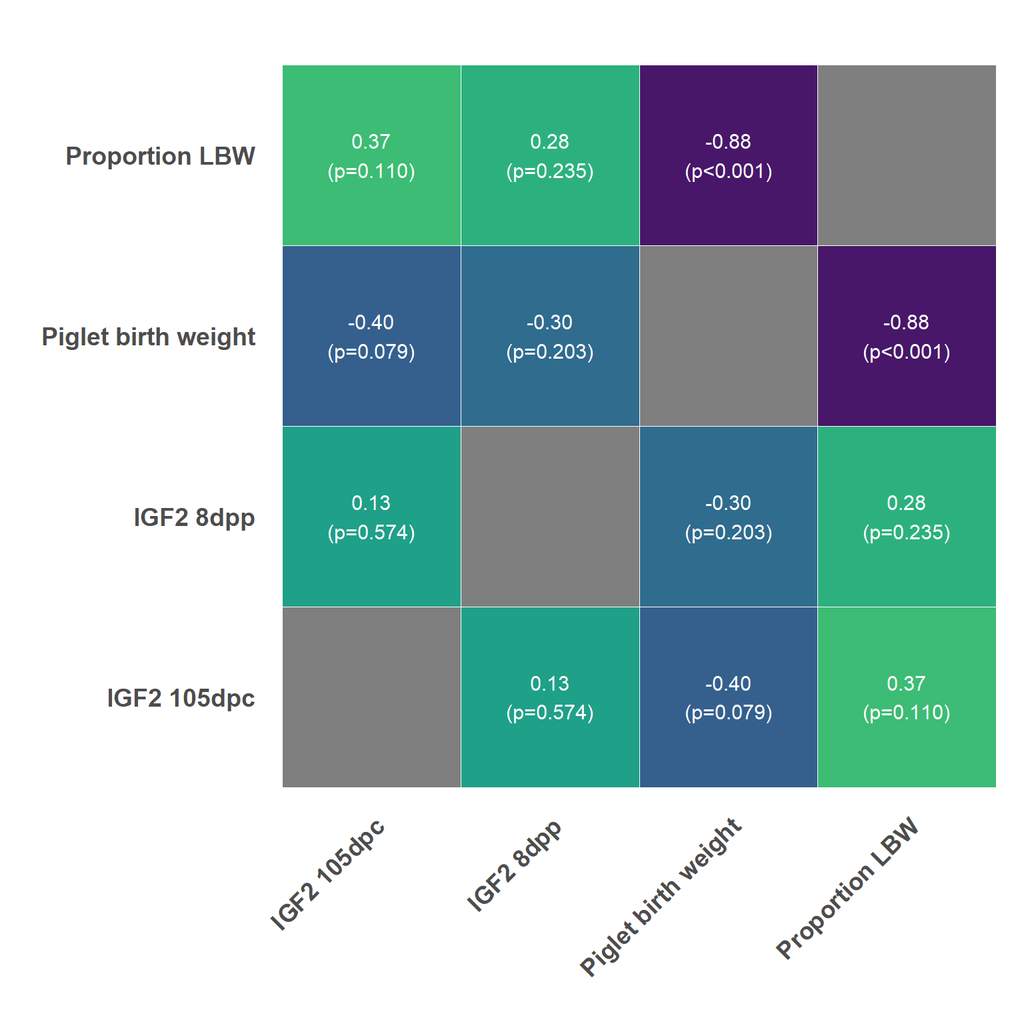

```r
plot.corr
```

# Statistical model: general design

To correctly account for the nested data structure in the analysis using a linear mixed model with the `lmerTest` package in R, we need to account for the hierarchical structure in the data:

- Husbandry Level (conventional/ecological): Each sow is housed in either of the two facilities.
- Sow Level: Each sow gave birth 1, 2 or 3 times, so these events are nested within sows.
- Time Point Level: Measurements were taken before and after each birth, introducing repeated measures within each pregnancy.
- control for age of the sows

```r
contr = lmerControl(optimizer   = "bobyqa",
                    optCtrl     = list(maxfun = 10000000),
                    calc.derivs = FALSE)
```

# Cortisol serum

## Model

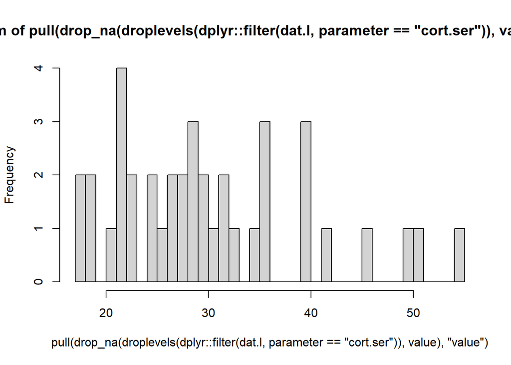

```r
hist(dat.l |>
       dplyr::filter(parameter == "cort.ser") |>
       droplevels() |>
       drop_na(value) |>
       pull("value"),
     breaks = 30)
```

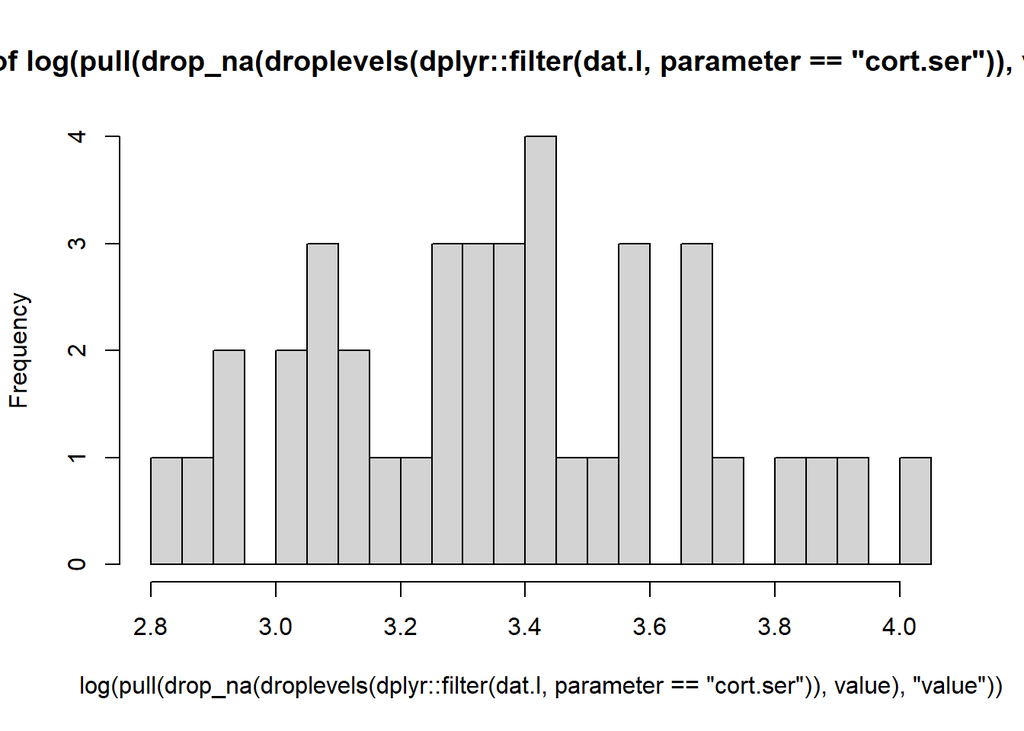

```r
hist(log(dat.l |>
         dplyr::filter(parameter == "cort.ser") |>
         droplevels() |>
         drop_na(value) |>
         pull("value")),
     breaks = 30)
```

Singularity issues if nested structure defined like `(1 | sow/litter.no)`.

```r
mod.cort1 <- lmerTest::lmer(log(value) ~
                              husbandry +
                              time +
                              # interaction term
                              husbandry : time +
                              # random intercept for sows and for each litter within sow
                              (1 | sow/litter.no),
                            data    = dat.l |>
                              dplyr::filter(parameter == "cort.ser") |>
                              droplevels() |>
                              drop_na(value),
                            REML    = TRUE,
                            control = contr)
```

```r
summary(mod.cort1)
```

```
Linear mixed model fit by REML. t-tests use Satterthwaite's method [
lmerModLmerTest]
Formula: log(value) ~ husbandry + time + husbandry:time + (1 | sow/litter.no)
   Data: drop_na(droplevels(dplyr::filter(dat.l, parameter == "cort.ser")),
    value)
Control: contr

REML criterion at convergence: 22.6

Scaled residuals:
     Min       1Q   Median       3Q      Max
-1.45942 -0.49449 -0.08495  0.57811  1.38490

Random effects:
 Groups        Name        Variance Std.Dev.
 litter.no:sow (Intercept) 0.02937  0.1714
 sow           (Intercept) 0.01239  0.1113
 Residual                  0.05441  0.2333
Number of obs: 39, groups:  litter.no:sow, 20; sow, 14

Fixed effects:
                             Estimate Std. Error       df t value Pr(>|t|)
(Intercept)                   3.40152    0.10154 14.82783  33.498 2.18e-15 ***
husbandryecological          -0.03632    0.14635 16.13178  -0.248    0.807
time8dpp                     -0.10436    0.10432 17.29836  -1.000    0.331
husbandryecological:time8dpp  0.11841    0.15039 17.69062   0.787    0.442
---
Signif. codes:  0 '***' 0.001 '**' 0.01 '*' 0.05 '.' 0.1 ' ' 1

Correlation of Fixed Effects:
            (Intr) hsbndr tm8dpp
hsbndryclgc -0.694
time8dpp    -0.514  0.356
hsbndrycl:8  0.356 -0.532 -0.694
```

```r
round(drop1(mod.cort1, test = 'Chisq'), 3)
```

```
Single term deletions using Satterthwaite's method:

Model:
log(value) ~ husbandry + time + husbandry:time + (1 | sow/litter.no)
               Sum Sq Mean Sq NumDF  DenDF F value Pr(>F)
husbandry:time  0.034   0.034     1 17.691    0.62  0.442
```

Without significant interactions, choose `type = 2`. With significant interactions, choose `type = 3`.

```r
car::Anova(mod.cort1,
           test.statistic = "Chisq",
           type = 2)
```

```
Analysis of Deviance Table (Type II Wald chisquare tests)

Response: log(value)
                Chisq Df Pr(>Chisq)
husbandry      0.0406  1     0.8404
time           0.3976  1     0.5283
husbandry:time 0.6199  1     0.4311
```

```r
car::Anova(mod.cort1,
           test.statistic = "F",
           type = 2)
```

```
Analysis of Deviance Table (Type II Wald F tests with Kenward-Roger df)

Response: log(value)
                    F Df Df.res Pr(>F)
husbandry      0.0388  1 10.877 0.8474
time           0.4022  1 17.439 0.5342
husbandry:time 0.6151  1 17.473 0.4434
```

## Model diagnostics

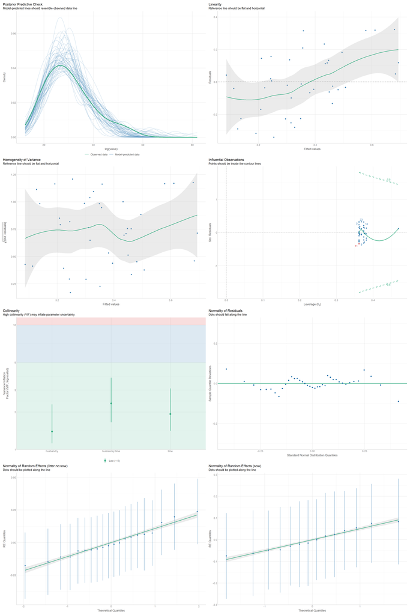

```r
performance::check_model(mod.cort1)
```

## Emmeans & Effect sizes

### Husbandry

Emmeans:

```r
emm <- emmeans(mod.cort1,
        pairwise ~ husbandry,
        data    = dat.l |>
          dplyr::filter(parameter == "cort.ser") |>
          droplevels() |>
          drop_na(value),
        adjust  = "tukey",
        lmer.df = "satterthwaite",
        type    = "response")
```

```
NOTE: Results may be misleading due to involvement in interactions
```

```r
emm
```

```
$emmeans
 husbandry    response   SE   df lower.CL upper.CL
 conventional     28.5 2.48 8.61     23.4     34.7
 ecological       29.1 2.57 9.27     23.9     35.5

Results are averaged over the levels of: time
Degrees-of-freedom method: satterthwaite
Confidence level used: 0.95
Intervals are back-transformed from the log scale

$contrasts
 contrast                  ratio    SE   df null t.ratio p.value
 conventional / ecological 0.977 0.121 8.93    1  -0.185  0.8577

Results are averaged over the levels of: time
Degrees-of-freedom method: satterthwaite
Tests are performed on the log scale
```

Effect sizes:

```r
eff_size(emm,
         sigma = sigma(mod.cort1),      # Residual standard deviation from model
         edf = df.residual(mod.cort1))  # Residual degrees of freedom
```

```
Since 'object' is a list, we are using the contrasts already present.
```

```
 contrast                    estimate    SE   df lower.CL upper.CL
 (conventional - ecological)  -0.0981 0.532 8.93     -1.3     1.11

Results are averaged over the levels of: time
sigma used for effect sizes: 0.2333
Degrees-of-freedom method: inherited from satterthwaite when re-gridding
Confidence level used: 0.95
```

### Time point

Emmeans:

```r
emm <- emmeans(mod.cort1,
        pairwise ~ time,
        data    = dat.l |>
          dplyr::filter(parameter == "cort.ser") |>
          droplevels() |>
          drop_na(value),
        adjust  = "tukey",
        lmer.df = "satterthwaite",
        type    = "response")
```

```
NOTE: Results may be misleading due to involvement in interactions
```

```r
emm
```

```
$emmeans
 time   response   SE   df lower.CL upper.CL
 105dpc     29.5 2.16 16.1     25.2     34.4
 8dpp       28.2 2.02 14.8     24.2     32.8

Results are averaged over the levels of: husbandry
Degrees-of-freedom method: satterthwaite
Confidence level used: 0.95
Intervals are back-transformed from the log scale

$contrasts
 contrast      ratio     SE   df null t.ratio p.value
 105dpc / 8dpp  1.05 0.0787 17.7    1   0.600  0.5558

Results are averaged over the levels of: husbandry
Degrees-of-freedom method: satterthwaite
Tests are performed on the log scale
```

Effect sizes:

```r
eff_size(emm,
         sigma = sigma(mod.cort1),
         edf = df.residual(mod.cort1))
```

```
Since 'object' is a list, we are using the contrasts already present.
```

```
 contrast        estimate    SE   df lower.CL upper.CL
 (105dpc - 8dpp)    0.194 0.323 17.7   -0.486    0.874

Results are averaged over the levels of: husbandry
sigma used for effect sizes: 0.2333
Degrees-of-freedom method: inherited from satterthwaite when re-gridding
Confidence level used: 0.95
```

### Husbandry:Time point

Emmeans:

```r
emm.cort1_ht <- emmeans(mod.cort1,
                        pairwise ~ husbandry|time,
                        data    = dat.l |>
                          dplyr::filter(parameter == "cort.ser") |>
                          droplevels() |>
                          drop_na(value),
                        adjust  = "tukey",
                        lmer.df = "satterthwaite",
                        type    = "response")

emm.cort1_ht
```

```
$emmeans
time = 105dpc:
 husbandry    response   SE   df lower.CL upper.CL
 conventional     30.0 3.05 14.8     24.2     37.3
 ecological       28.9 3.05 17.4     23.2     36.1

time = 8dpp:
 husbandry    response   SE   df lower.CL upper.CL
 conventional     27.0 2.75 14.8     21.8     33.6
 ecological       29.3 2.98 14.8     23.6     36.5

Degrees-of-freedom method: satterthwaite
Confidence level used: 0.95
Intervals are back-transformed from the log scale

$contrasts
time = 105dpc:
 contrast                  ratio    SE   df null t.ratio p.value
 conventional / ecological 1.037 0.152 16.1    1   0.248  0.8071

time = 8dpp:
 contrast                  ratio    SE   df null t.ratio p.value
 conventional / ecological 0.921 0.132 14.8    1  -0.572  0.5762

Degrees-of-freedom method: satterthwaite
Tests are performed on the log scale
```

Effect sizes:

```r
eff_size(emm.cort1_ht,
         sigma = sigma(mod.cort1),
         edf = df.residual(mod.cort1))
```

```
Since 'object' is a list, we are using the contrasts already present.
```

```
time = 105dpc:
 contrast                    estimate    SE   df lower.CL upper.CL
 (conventional - ecological)    0.156 0.628 16.1    -1.17    1.485

time = 8dpp:
 contrast                    estimate    SE   df lower.CL upper.CL
 (conventional - ecological)   -0.352 0.617 14.8    -1.67    0.965

sigma used for effect sizes: 0.2333
Degrees-of-freedom method: inherited from satterthwaite when re-gridding
Confidence level used: 0.95
```

### Time point:Husbandry

Emmeans:

```r
emm.cort1_th <- emmeans(mod.cort1,
                        pairwise ~ time|husbandry,
                        data    = dat.l |>
                          dplyr::filter(parameter == "cort.ser") |>
                          droplevels() |>
                          drop_na(value),
                        adjust  = "tukey",
                        lmer.df = "satterthwaite",
                        type    = "response")

emm.cort1_th
```

```
$emmeans
husbandry = conventional:
 time   response   SE   df lower.CL upper.CL
 105dpc     30.0 3.05 14.8     24.2     37.3
 8dpp       27.0 2.75 14.8     21.8     33.6

husbandry = ecological:
 time   response   SE   df lower.CL upper.CL
 105dpc     28.9 3.05 17.4     23.2     36.1
 8dpp       29.3 2.98 14.8     23.6     36.5

Degrees-of-freedom method: satterthwaite
Confidence level used: 0.95
Intervals are back-transformed from the log scale

$contrasts
husbandry = conventional:
 contrast      ratio    SE   df null t.ratio p.value
 105dpc / 8dpp 1.110 0.116 17.3    1   1.000  0.3309

husbandry = ecological:
 contrast      ratio    SE   df null t.ratio p.value
 105dpc / 8dpp 0.986 0.107 18.1    1  -0.130  0.8982

Degrees-of-freedom method: satterthwaite
Tests are performed on the log scale
```

Effect sizes:

```r
eff_size(emm.cort1_th,
         sigma = sigma(mod.cort1),
         edf = df.residual(mod.cort1))
```

```
Since 'object' is a list, we are using the contrasts already present.
```

```
husbandry = conventional:
 contrast        estimate    SE   df lower.CL upper.CL
 (105dpc - 8dpp)   0.4474 0.451 17.3   -0.502    1.397

husbandry = ecological:
 contrast        estimate    SE   df lower.CL upper.CL
 (105dpc - 8dpp)  -0.0602 0.464 18.1   -1.036    0.915

sigma used for effect sizes: 0.2333
Degrees-of-freedom method: inherited from satterthwaite when re-gridding
Confidence level used: 0.95
```

## Plot

```r
plot.cort1 <- dat.l  |>
  dplyr::filter(parameter == "cort.ser") |>
  droplevels() |>
  drop_na(value) |>
  # make plot
  mutate(jit = jitter(as.numeric(time), 0.3)) |>
  ggplot(aes(y   = value)) +
  geom_boxplot(aes(x   = time,
                   fill = husbandry),
               col = "black",
               outlier.shape = NA, width = 0.5) +
  geom_jitter(aes(x   = time,
                  fill = husbandry),
              col = "black",
              position = position_jitterdodge(jitter.width  = 0.15,
                                              dodge.width   = 0.5),
              size = 2, alpha = 0.7,
              show.legend = FALSE) +
  scale_fill_manual(labels = c("Conventional",
                               "Ecological"),
                    values = c("#FFA040", "#008000")) +
  scale_y_continuous(lim = c(0, 60),
                     breaks = seq(0, 60, 20),
                     minor_breaks = seq(0, 60, by = 2) ) +
  scale_x_discrete(labels= c("105dpc", "8dpp")) +
  labs(x = "",
       y = "Cortisol (serum) [ng/ml]",
       fill = "Husbandry") +
  my_theme +
  theme(legend.position = "top") +
  guides(y = guide_axis(minor.ticks = TRUE),
         fill = guide_legend(override.aes = list(linetype = 0, size  = 5)))
```

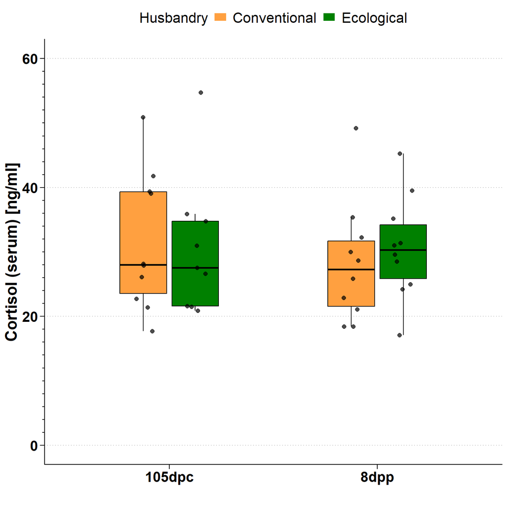

```r
plot.cort1
```

# Cortisol saliva

## Model

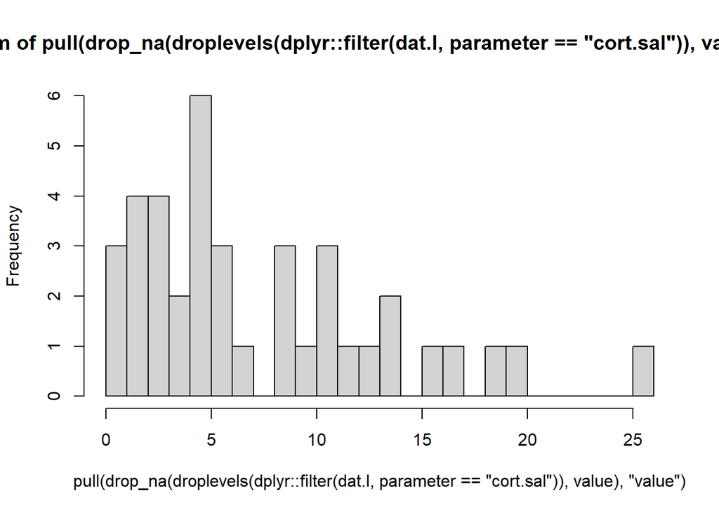

```r
hist(dat.l |>
       dplyr::filter(parameter == "cort.sal") |>
       droplevels() |>
       drop_na(value) |>
       pull("value"),
     breaks = 30)
```

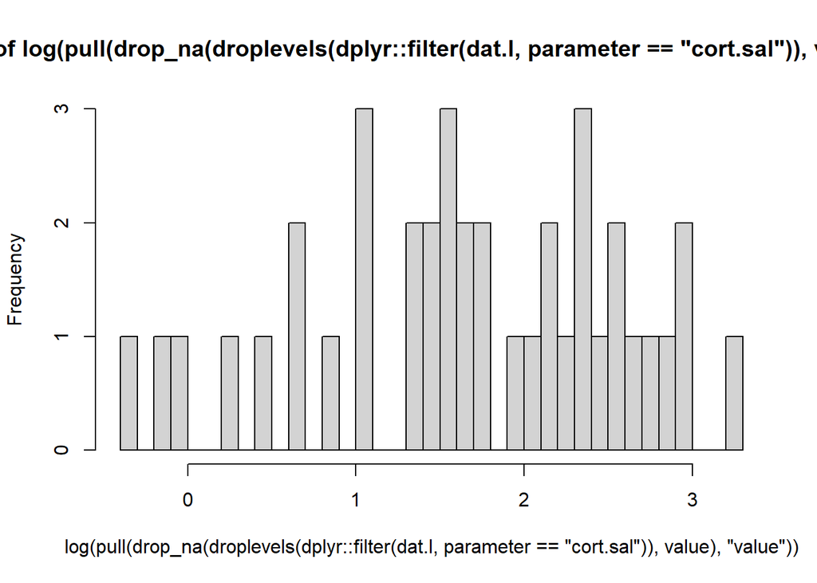

```r
hist(log(dat.l |>
         dplyr::filter(parameter == "cort.sal") |>
         droplevels() |>
         drop_na(value) |>
         pull("value")),
     breaks = 30)
```

Singularity issues if nested structure defined like `(1 | sow/litter.no)`.

```r
mod.cort2 <- lmerTest::lmer(log(value) ~
                              husbandry +
                              time +
                              # interaction term
                              husbandry : time +
                              # random intercept for sows and for each litter within sow
                              (1 | sow/litter.no),
                            data    = dat.l |>
                              dplyr::filter(parameter == "cort.sal") |>
                              droplevels() |>
                              drop_na(value),
                            REML    = TRUE,
                            control = contr)
```

```
boundary (singular) fit: see help('isSingular')
```

```r
summary(mod.cort2)
```

```
Linear mixed model fit by REML. t-tests use Satterthwaite's method [
lmerModLmerTest]
Formula: log(value) ~ husbandry + time + husbandry:time + (1 | sow/litter.no)
   Data: drop_na(droplevels(dplyr::filter(dat.l, parameter == "cort.sal")),
    value)
Control: contr

REML criterion at convergence: 101.8

Scaled residuals:
     Min       1Q   Median       3Q      Max
-2.29670 -0.33630  0.06505  0.77409  1.36353

Random effects:
 Groups        Name        Variance Std.Dev.
 litter.no:sow (Intercept) 0.000    0.0000
 sow           (Intercept) 0.000    0.0000
 Residual                  0.827    0.9094
Number of obs: 39, groups:  litter.no:sow, 20; sow, 14

Fixed effects:
                             Estimate Std. Error      df t value Pr(>|t|)
(Intercept)                    2.0473     0.3031 35.0000   6.754 7.96e-08 ***
husbandryecological           -0.4572     0.4179 35.0000  -1.094   0.2813
time8dpp                      -0.7537     0.4179 35.0000  -1.804   0.0799 .
husbandryecological:time8dpp   0.9303     0.5831 35.0000   1.595   0.1196
---
Signif. codes:  0 '***' 0.001 '**' 0.01 '*' 0.05 '.' 0.1 ' ' 1

Correlation of Fixed Effects:
            (Intr) hsbndr tm8dpp
hsbndryclgc -0.725
time8dpp    -0.725  0.526
hsbndrycl:8  0.520 -0.717 -0.717
optimizer (bobyqa) convergence code: 0 (OK)
boundary (singular) fit: see help('isSingular')
```

```r
round(drop1(mod.cort2, test = 'Chisq'), 3)
```

```
Single term deletions using Satterthwaite's method:

Model:
log(value) ~ husbandry + time + husbandry:time + (1 | sow/litter.no)
               Sum Sq Mean Sq NumDF DenDF F value Pr(>F)
husbandry:time  2.105   2.105     1    35   2.546   0.12
```

Without significant interactions, choose `type = 2`. With significant interactions, choose `type = 3`.

```r
car::Anova(mod.cort2,
           test.statistic = "Chisq",
           type = 2)
```

```
Analysis of Deviance Table (Type II Wald chisquare tests)

Response: log(value)
                Chisq Df Pr(>Chisq)
husbandry      0.0049  1     0.9439
time           0.8969  1     0.3436
husbandry:time 2.5455  1     0.1106
```

```r
car::Anova(mod.cort2,
           test.statistic = "F",
           type = 2)
```

```
Analysis of Deviance Table (Type II Wald F tests with Kenward-Roger df)

Response: log(value)
                    F Df  Df.res Pr(>F)
husbandry      0.0058  1  9.7306 0.9409
time           0.8843  1 17.6972 0.3597
husbandry:time 2.5370  1 17.7258 0.1289
```

## Model diagnostics

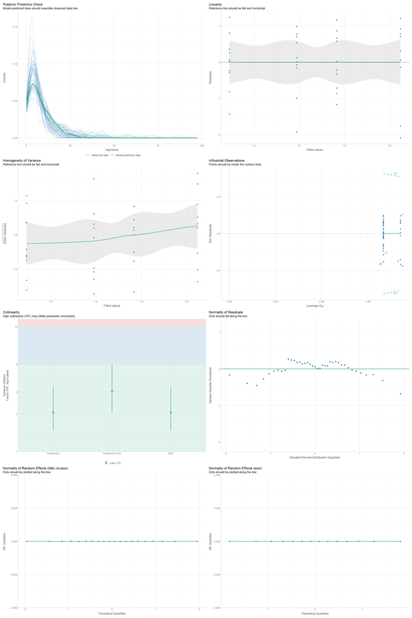

```r
performance::check_model(mod.cort2)
```

## Emmeans & Effect sizes

### Husbandry

Emmeans:

```r
emm <- emmeans(mod.cort2,
        pairwise ~ husbandry,
        data    = dat.l |>
          dplyr::filter(parameter == "cort.sal") |>
          droplevels() |>
          drop_na(value),
        adjust  = "tukey",
        lmer.df = "satterthwaite",
        type    = "response")
```

```
NOTE: Results may be misleading due to involvement in interactions
```

```r
emm
```

```
$emmeans
 husbandry    response   SE df lower.CL upper.CL
 conventional     5.31 1.11 35     3.48     8.12
 ecological       5.36 1.09 35     3.55     8.09

Results are averaged over the levels of: time
Degrees-of-freedom method: satterthwaite
Confidence level used: 0.95
Intervals are back-transformed from the log scale

$contrasts
 contrast                  ratio    SE df null t.ratio p.value
 conventional / ecological 0.992 0.289 35    1  -0.027  0.9785

Results are averaged over the levels of: time
Degrees-of-freedom method: satterthwaite
Tests are performed on the log scale
```

Effect sizes:

```r
eff_size(emm,
         sigma = sigma(mod.cort2),
         edf = df.residual(mod.cort2))
```

```
Since 'object' is a list, we are using the contrasts already present.
```

```
 contrast                    estimate    SE df lower.CL upper.CL
 (conventional - ecological) -0.00871 0.321 35    -0.66    0.642

Results are averaged over the levels of: time
sigma used for effect sizes: 0.9094
Degrees-of-freedom method: inherited from satterthwaite when re-gridding
Confidence level used: 0.95
```

### Time point

Emmeans:

```r
emm <- emmeans(mod.cort2,
        pairwise ~ time,
        data    = dat.l |>
          dplyr::filter(parameter == "cort.sal") |>
          droplevels() |>
          drop_na(value),
        adjust  = "tukey",
        lmer.df = "satterthwaite",
        type    = "response")
```

```
NOTE: Results may be misleading due to involvement in interactions
```

```r
emm
```

```
$emmeans
 time   response    SE df lower.CL upper.CL
 105dpc     6.16 1.290 35     4.03     9.42
 8dpp       4.62 0.939 35     3.06     6.98

Results are averaged over the levels of: husbandry
Degrees-of-freedom method: satterthwaite
Confidence level used: 0.95
Intervals are back-transformed from the log scale

$contrasts
 contrast      ratio    SE df null t.ratio p.value
 105dpc / 8dpp  1.33 0.389 35    1   0.990  0.3291

Results are averaged over the levels of: husbandry
Degrees-of-freedom method: satterthwaite
Tests are performed on the log scale
```

Effect sizes:

```r
eff_size(emm,
         sigma = sigma(mod.cort2),
         edf = df.residual(mod.cort2))
```

```
Since 'object' is a list, we are using the contrasts already present.
```

```
 contrast        estimate    SE df lower.CL upper.CL
 (105dpc - 8dpp)    0.317 0.323 35   -0.338    0.973

Results are averaged over the levels of: husbandry
sigma used for effect sizes: 0.9094
Degrees-of-freedom method: inherited from satterthwaite when re-gridding
Confidence level used: 0.95
```

### Husbandry:Time point

Emmeans:

```r
emm.cort2_ht <- emmeans(mod.cort2,
                        pairwise ~ husbandry|time,
                        data    = dat.l |>
                          dplyr::filter(parameter == "cort.sal") |>
                          droplevels() |>
                          drop_na(value),
                        adjust  = "tukey",
                        lmer.df = "satterthwaite",
                        type    = "response")

emm.cort2_ht
```

```
$emmeans
time = 105dpc:
 husbandry    response   SE df lower.CL upper.CL
 conventional     7.75 2.35 35     4.19    14.34
 ecological       4.90 1.41 35     2.74     8.79

time = 8dpp:
 husbandry    response   SE df lower.CL upper.CL
 conventional     3.65 1.05 35     2.03     6.54
 ecological       5.85 1.68 35     3.26    10.49

Degrees-of-freedom method: satterthwaite
Confidence level used: 0.95
Intervals are back-transformed from the log scale

$contrasts
time = 105dpc:
 contrast                  ratio    SE df null t.ratio p.value
 conventional / ecological 1.580 0.660 35    1   1.094  0.2813

time = 8dpp:
 contrast                  ratio    SE df null t.ratio p.value
 conventional / ecological 0.623 0.253 35    1  -1.163  0.2526

Degrees-of-freedom method: satterthwaite
Tests are performed on the log scale
```

Effect sizes:

```r
eff_size(emm.cort2_ht,
         sigma = sigma(mod.cort2),
         edf = df.residual(mod.cort2))
```

```
Since 'object' is a list, we are using the contrasts already present.
```

```
time = 105dpc:
 contrast                    estimate    SE df lower.CL upper.CL
 (conventional - ecological)    0.503 0.464 35   -0.439    1.444

time = 8dpp:
 contrast                    estimate    SE df lower.CL upper.CL
 (conventional - ecological)   -0.520 0.452 35   -1.438    0.397

sigma used for effect sizes: 0.9094
Degrees-of-freedom method: inherited from satterthwaite when re-gridding
Confidence level used: 0.95
```

### Time point:Husbandry

Emmeans:

```r
emm.cort2_th <- emmeans(mod.cort2,
                        pairwise ~ time|husbandry,
                        data    = dat.l |>
                          dplyr::filter(parameter == "cort.sal") |>
                          droplevels() |>
                          drop_na(value),
                        adjust  = "tukey",
                        lmer.df = "satterthwaite",
                        type    = "response")

emm.cort2_th
```

```
$emmeans
husbandry = conventional:
 time   response   SE df lower.CL upper.CL
 105dpc     7.75 2.35 35     4.19    14.34
 8dpp       3.65 1.05 35     2.03     6.54

husbandry = ecological:
 time   response   SE df lower.CL upper.CL
 105dpc     4.90 1.41 35     2.74     8.79
 8dpp       5.85 1.68 35     3.26    10.49

Degrees-of-freedom method: satterthwaite
Confidence level used: 0.95
Intervals are back-transformed from the log scale

$contrasts
husbandry = conventional:
 contrast      ratio    SE df null t.ratio p.value
 105dpc / 8dpp 2.125 0.888 35    1   1.804  0.0799

husbandry = ecological:
 contrast      ratio    SE df null t.ratio p.value
 105dpc / 8dpp 0.838 0.341 35    1  -0.434  0.6668

Degrees-of-freedom method: satterthwaite
Tests are performed on the log scale
```

Effect sizes:

```r
eff_size(emm.cort2_th,
         sigma = sigma(mod.cort2),
         edf = df.residual(mod.cort2))
```

```
Since 'object' is a list, we are using the contrasts already present.
```

```
husbandry = conventional:
 contrast        estimate    SE df lower.CL upper.CL
 (105dpc - 8dpp)    0.829 0.471 35   -0.127    1.785

husbandry = ecological:
 contrast        estimate    SE df lower.CL upper.CL
 (105dpc - 8dpp)   -0.194 0.448 35   -1.103    0.715

sigma used for effect sizes: 0.9094
Degrees-of-freedom method: inherited from satterthwaite when re-gridding
Confidence level used: 0.95
```

## Plot

```r
plot.cort2 <- dat.l  |>
  dplyr::filter(parameter == "cort.sal") |>
  droplevels() |>
  drop_na(value) |>
  # make plot
  mutate(jit = jitter(as.numeric(time), 0.3)) |>
  ggplot(aes(y   = value)) +
  geom_boxplot(aes(x   = time,
                   fill = husbandry),
               col = "black",
               outlier.shape = NA, width = 0.5) +
  geom_jitter(aes(x   = time,
                  fill = husbandry),
              col = "black",
              position = position_jitterdodge(jitter.width  = 0.15,
                                              dodge.width   = 0.5),
              size = 2, alpha = 0.7,
              show.legend = FALSE) +
  scale_fill_manual(labels = c("Conventional",
                               "Ecological"),
                    values = c("#FFA040", "#008000")) +
  scale_y_continuous(lim = c(0, 30),
                     breaks = seq(0, 30, 10),
                     minor_breaks = seq(0, 30, by = 2) ) +
  scale_x_discrete(labels= c("105dpc", "8dpp")) +
  labs(x = "",
       y = "Cortisol (saliva) [ng/mg protein]",
       fill = "Husbandry") +
  my_theme +
  theme(legend.position = "top") +
  guides(y = guide_axis(minor.ticks = TRUE),
         fill = guide_legend(override.aes = list(linetype = 0, size  = 5)))
```

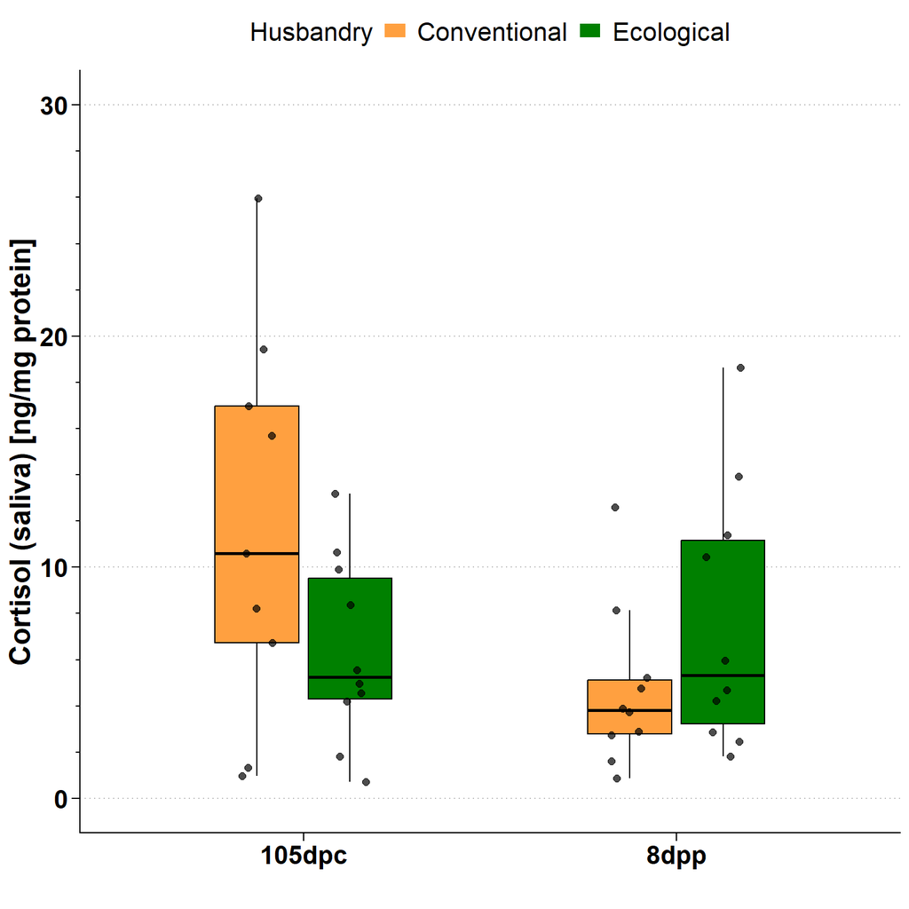

```r
plot.cort2
```

# IGF bioactivity

## Model

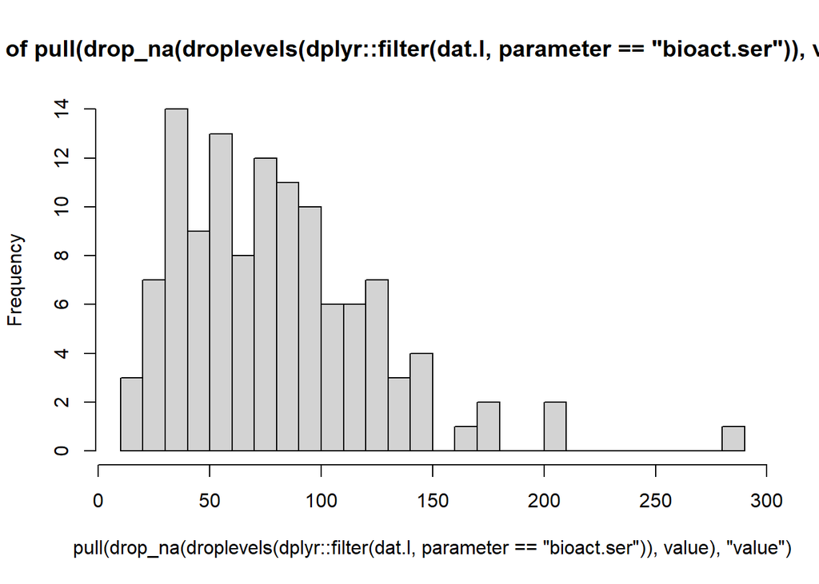

```r
hist(dat.l |>
       dplyr::filter(parameter == "bioact.ser") |>
       droplevels() |>
       drop_na(value) |>
       pull("value"),
     breaks = 30)
```

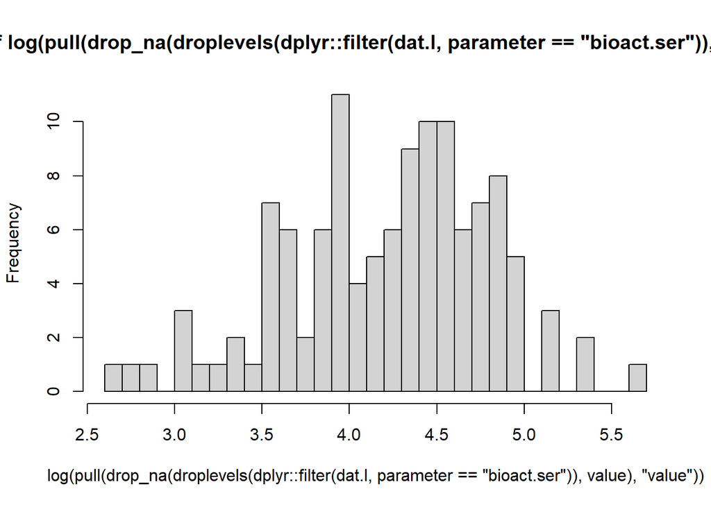

```r
hist(log(dat.l |>
         dplyr::filter(parameter == "bioact.ser") |>
         droplevels() |>
         drop_na(value) |>
         pull("value")),
     breaks = 30)
```

Singularity issues if nested structure defined like `(1 | sow/litter.no)`.

```r
mod.bioact <- lmerTest::lmer(log(value) ~
                               husbandry +
                               time +
                               # interaction term
                               husbandry : time +
                               # random intercept for sows and for each litter within sow
                               (1 | sow/litter.no),
                             data    = dat.l |>
                               dplyr::filter(parameter == "bioact.ser") |>
                               drop_na(value) |>
                               dplyr::filter(time != "30dpc") |>
                               droplevels(),
                            REML    = TRUE,
                            control = contr)
```

```
boundary (singular) fit: see help('isSingular')
```

```r
summary(mod.bioact)
```

```
Linear mixed model fit by REML. t-tests use Satterthwaite's method [
lmerModLmerTest]
Formula: log(value) ~ husbandry + time + husbandry:time + (1 | sow/litter.no)
   Data: droplevels(dplyr::filter(drop_na(dplyr::filter(dat.l, parameter ==
    "bioact.ser"), value), time != "30dpc"))
Control: contr

REML criterion at convergence: 125.7

Scaled residuals:
     Min       1Q   Median       3Q      Max
-2.44426 -0.47004  0.08705  0.53359  1.70672

Random effects:
 Groups        Name        Variance  Std.Dev.
 litter.no:sow (Intercept) 1.578e-01 3.972e-01
 sow           (Intercept) 3.789e-16 1.946e-08
 Residual                  1.475e-01 3.841e-01
Number of obs: 80, groups:  litter.no:sow, 40; sow, 15

Fixed effects:
                             Estimate Std. Error       df t value Pr(>|t|)
(Intercept)                   4.36388    0.12355 59.97872  35.321   <2e-16 ***
husbandryecological          -0.42643    0.17473 59.97872  -2.441   0.0176 *
time8dpp                      0.01946    0.12145 38.00000   0.160   0.8735
husbandryecological:time8dpp  0.14203    0.17176 38.00000   0.827   0.4135
---
Signif. codes:  0 '***' 0.001 '**' 0.01 '*' 0.05 '.' 0.1 ' ' 1

Correlation of Fixed Effects:
            (Intr) hsbndr tm8dpp
hsbndryclgc -0.707
time8dpp    -0.492  0.348
hsbndrycl:8  0.348 -0.492 -0.707
optimizer (bobyqa) convergence code: 0 (OK)
boundary (singular) fit: see help('isSingular')
```

```r
round(drop1(mod.bioact, test = 'Chisq'), 3)
```

```
Single term deletions using Satterthwaite's method:

Model:
log(value) ~ husbandry + time + husbandry:time + (1 | sow/litter.no)
               Sum Sq Mean Sq NumDF DenDF F value Pr(>F)
husbandry:time  0.101   0.101     1    38   0.684  0.413
```

Without significant interactions, choose `type = 2`. With significant interactions, choose `type = 3`.

```r
car::Anova(mod.bioact,
           test.statistic = "Chisq",
           type = 2)
```

```
Analysis of Deviance Table (Type II Wald chisquare tests)

Response: log(value)
                Chisq Df Pr(>Chisq)
husbandry      5.4558  1     0.0195 *
time           1.1099  1     0.2921
husbandry:time 0.6838  1     0.4083
---
Signif. codes:  0 '***' 0.001 '**' 0.01 '*' 0.05 '.' 0.1 ' ' 1
```

```r
car::Anova(mod.bioact,
           test.statistic = "F",
           type = 2)
```

```
Analysis of Deviance Table (Type II Wald F tests with Kenward-Roger df)

Response: log(value)
                    F Df Df.res Pr(>F)
husbandry      5.3823  1 11.923 0.0389 *
time           1.1099  1 38.000 0.2987
husbandry:time 0.6838  1 38.000 0.4135
---
Signif. codes:  0 '***' 0.001 '**' 0.01 '*' 0.05 '.' 0.1 ' ' 1
```

## Model diagnostics

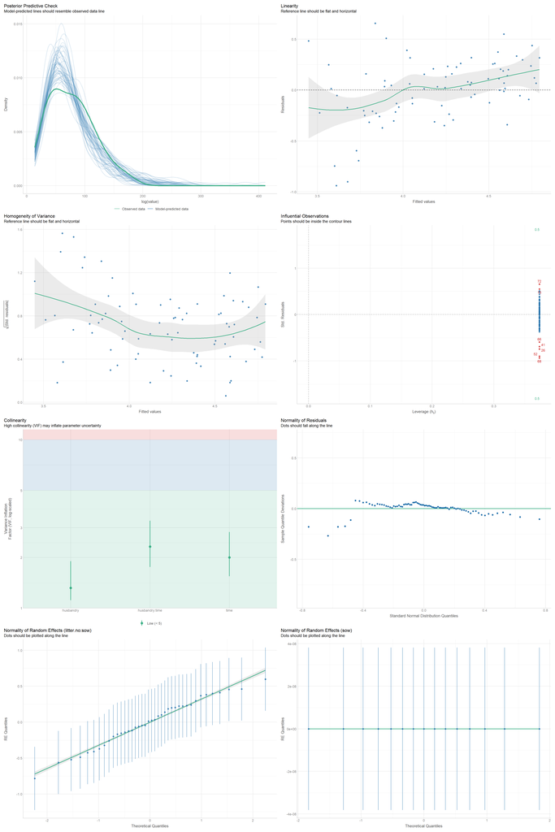

```r
performance::check_model(mod.bioact)
```

## Emmeans & Effect sizes

### Husbandry

Emmeans:

```r
emm <- emmeans(mod.bioact,
        pairwise ~ husbandry,
        data    = dat.l |>
          dplyr::filter(parameter == "bioact.ser") |>
          drop_na(value) |>
          dplyr::filter(time != "30dpc") |>
          droplevels(),
        adjust  = "tukey",
        lmer.df = "satterthwaite",
        type    = "response")
```

```
NOTE: Results may be misleading due to involvement in interactions
```

```r
emm
```

```
$emmeans
 husbandry    response   SE df lower.CL upper.CL
 conventional     79.3 8.54 38     63.8     98.6
 ecological       55.6 5.98 38     44.7     69.1

Results are averaged over the levels of: time
Degrees-of-freedom method: satterthwaite
Confidence level used: 0.95
Intervals are back-transformed from the log scale

$contrasts
 contrast                  ratio    SE df null t.ratio p.value
 conventional / ecological  1.43 0.217 38    1   2.336  0.0249

Results are averaged over the levels of: time
Degrees-of-freedom method: satterthwaite
Tests are performed on the log scale
```

Effect sizes:

```r
eff_size(emm,
         sigma = sigma(mod.bioact),
         edf = df.residual(mod.bioact))
```

```
Since 'object' is a list, we are using the contrasts already present.
```

```
 contrast                    estimate    SE df lower.CL upper.CL
 (conventional - ecological)    0.925 0.404 38    0.109     1.74

Results are averaged over the levels of: time
sigma used for effect sizes: 0.3841
Degrees-of-freedom method: inherited from satterthwaite when re-gridding
Confidence level used: 0.95
```

### Time point

Emmeans:

```r
emm <- emmeans(mod.cort2,
        pairwise ~ time,
        data    = dat.l |>
          dplyr::filter(parameter == "bioact.ser") |>
          drop_na(value) |>
          dplyr::filter(time != "30dpc") |>
          droplevels(),
        adjust  = "tukey",
        lmer.df = "satterthwaite",
        type    = "response")
```

```
NOTE: Results may be misleading due to involvement in interactions
```

```r
emm
```

[output not shown]

Effect sizes:

```r
eff_size(emm,
         sigma = sigma(mod.bioact),
         edf = df.residual(mod.bioact))
```

```
Since 'object' is a list, we are using the contrasts already present.
```

[output not shown]

### Husbandry:Time point

Emmeans:

```r
emm.bioact_ht <- emmeans(mod.bioact,
                         pairwise ~ husbandry|time,
                         data    = dat.l |>
                           dplyr::filter(parameter == "bioact.ser") |>
                           drop_na(value) |>
                           dplyr::filter(time != "30dpc") |>
                           droplevels(),
                         adjust  = "tukey",
                         lmer.df = "satterthwaite",
                         type    = "response")

emm.bioact_ht
```

```
$emmeans
time = 105dpc:
 husbandry    response   SE df lower.CL upper.CL
 conventional     78.6 9.71 60     61.4    100.6
 ecological       51.3 6.34 60     40.1     65.7

time = 8dpp:
 husbandry    response   SE df lower.CL upper.CL
 conventional     80.1 9.90 60     62.6    102.6
 ecological       60.3 7.45 60     47.1     77.2

Degrees-of-freedom method: satterthwaite
Confidence level used: 0.95
Intervals are back-transformed from the log scale

$contrasts
time = 105dpc:
 contrast                  ratio    SE df null t.ratio p.value
 conventional / ecological  1.53 0.268 60    1   2.441  0.0176

time = 8dpp:
 contrast                  ratio    SE df null t.ratio p.value
 conventional / ecological  1.33 0.232 60    1   1.628  0.1088

Degrees-of-freedom method: satterthwaite
Tests are performed on the log scale
```

Effect sizes:

```r
eff_size(emm.bioact_ht,
         sigma = sigma(mod.bioact),
         edf = df.residual(mod.bioact))
```

```
Since 'object' is a list, we are using the contrasts already present.
```

```
time = 105dpc:
 contrast                    estimate    SE df lower.CL upper.CL
 (conventional - ecological)    1.110 0.464 60    0.182     2.04

time = 8dpp:
 contrast                    estimate    SE df lower.CL upper.CL
 (conventional - ecological)    0.741 0.459 60   -0.178     1.66

sigma used for effect sizes: 0.3841
Degrees-of-freedom method: inherited from satterthwaite when re-gridding
Confidence level used: 0.95
```

### Time point:Husbandry

Emmeans:

```r
emm.bioact_th <- emmeans(mod.bioact,
                         pairwise ~ time|husbandry,
                         data    = dat.l |>
                           dplyr::filter(parameter == "bioact.ser") |>
                           drop_na(value) |>
                           dplyr::filter(time != "30dpc") |>
                           droplevels(),
                         adjust  = "tukey",
                         lmer.df = "satterthwaite",
                         type    = "response")

emm.bioact_th
```

```
$emmeans
husbandry = conventional:
 time   response   SE df lower.CL upper.CL
 105dpc     78.6 9.71 60     61.4    100.6
 8dpp       80.1 9.90 60     62.6    102.6

husbandry = ecological:
 time   response   SE df lower.CL upper.CL
 105dpc     51.3 6.34 60     40.1     65.7
 8dpp       60.3 7.45 60     47.1     77.2

Degrees-of-freedom method: satterthwaite
Confidence level used: 0.95
Intervals are back-transformed from the log scale

$contrasts
husbandry = conventional:
 contrast      ratio    SE df null t.ratio p.value
 105dpc / 8dpp 0.981 0.119 38    1  -0.160  0.8735

husbandry = ecological:
 contrast      ratio    SE df null t.ratio p.value
 105dpc / 8dpp 0.851 0.103 38    1  -1.330  0.1916

Degrees-of-freedom method: satterthwaite
Tests are performed on the log scale
```

Effect sizes:

```r
eff_size(emm.bioact_th,
         sigma = sigma(mod.bioact),
         edf = df.residual(mod.bioact))
```

```
Since 'object' is a list, we are using the contrasts already present.
```

```
husbandry = conventional:
 contrast        estimate    SE df lower.CL upper.CL
 (105dpc - 8dpp)  -0.0507 0.316 38   -0.691    0.590

husbandry = ecological:
 contrast        estimate    SE df lower.CL upper.CL
 (105dpc - 8dpp)  -0.4205 0.318 38   -1.065    0.224

sigma used for effect sizes: 0.3841
Degrees-of-freedom method: inherited from satterthwaite when re-gridding
Confidence level used: 0.95
```

## Plot

Add significant contrasts to the plot:

```r
contr.bioact_ht <- contrast(emm.bioact_ht, method = "pairwise") |>
  as.data.frame() |>
  as_tibble() |>
  mutate(p.label = dplyr::case_when(
    p.value < 0.001 ~ "p < 0.001",
    p.value < 0.05  ~ sprintf("p = %.3f", p.value),
    TRUE            ~ NA_character_)) |>
  # for brackets
  mutate(
    group1 = "conventional",
    group2 = "ecological") |>
  mutate(
    x = as.numeric(time),
    xmin = x - 0.25 * 0.5,
    xmax = x + 0.25 * 0.5) |>
  mutate(y.position = 190) |>
  # only significant results
  dplyr::filter(!is.na(p.label))
```

```r
plot.bioact <- dat.l  |>
  dplyr::filter(parameter == "bioact.ser") |>
  drop_na(value) |>
  dplyr::filter(time != "30dpc") |>
  droplevels() |>
  # plot
  mutate(jit = jitter(as.numeric(time), 0.3)) |>
  ggplot(aes(y   = value)) +
  geom_boxplot(aes(x   = time,
                   fill = husbandry),
               col = "black",
               outlier.shape = NA, width = 0.5) +
  geom_jitter(aes(x   = time,
                  fill = husbandry),
              col = "black",
              position = position_jitterdodge(jitter.width  = 0.15,
                                              dodge.width   = 0.5),
              size = 2, alpha = 0.7,
              show.legend = FALSE) +
  ggpubr::stat_pvalue_manual(
    contr.bioact_ht,
    inherit.aes = FALSE,
    label = "p.label",
    xmin = "xmin",
    xmax = "xmax",
    y.position = "y.position",
    size = 14/.pt,
    bracket.size = 0.8,
    tip.length = 0.03,
    position = position_dodge(width = 0.5)) +
  scale_fill_manual(labels = c("Conventional",
                               "Ecological"),
                    values = c("#FFA040", "#008000")) +
  scale_y_continuous(breaks = seq(0, 200, 50),
                     minor_breaks = seq(0, 200, by = 10),
                     expand = expansion(mult = c(0.05, 0.1))) +
  # important to define limits of the coord system not of the y-axis
  coord_cartesian(ylim = c(0, 200), clip = "off") +
  scale_x_discrete(labels= c("105dpc", "8dpp")) +
  labs(x = "",
       y = "Normalized IGF-dependent bioactivity [%]",
       fill = "Husbandry") +
  my_theme +
  theme(legend.position = "top") +
  guides(y = guide_axis(minor.ticks = TRUE),
         fill = guide_legend(override.aes = list(linetype = 0, size  = 5)))
```

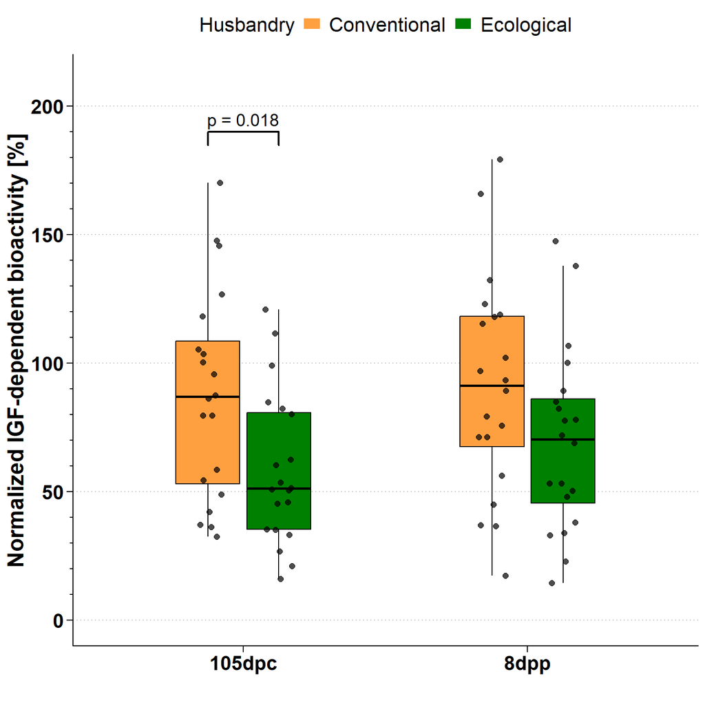

```r
plot.bioact
```

# IGF1 (serum)

## Model

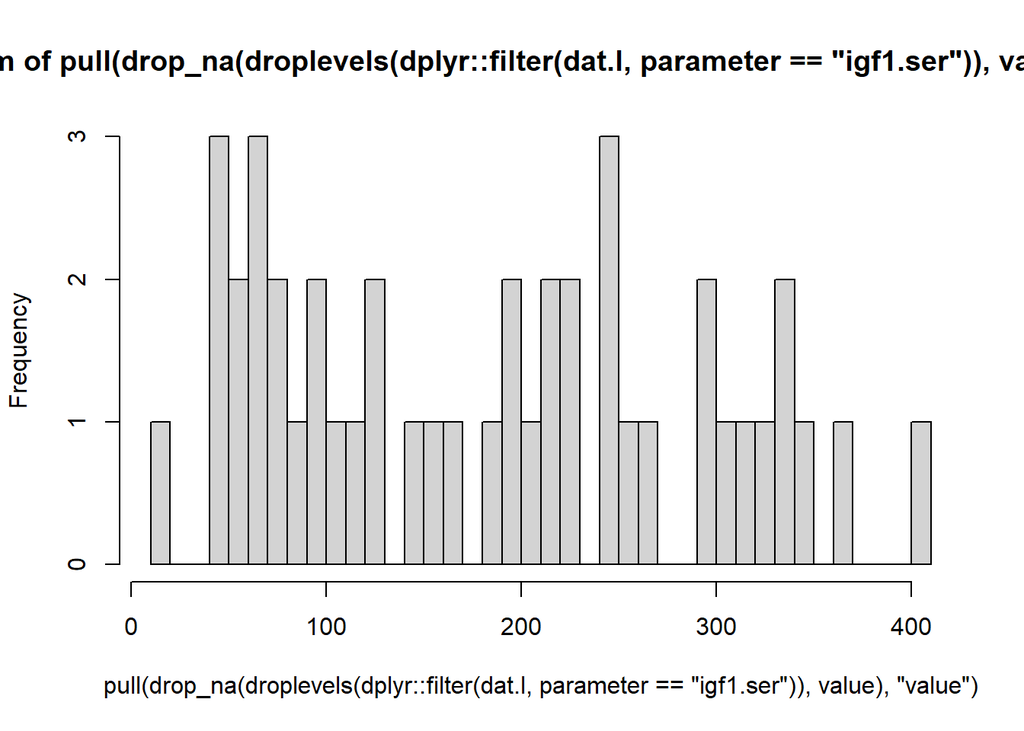

```r
hist(dat.l |>
       dplyr::filter(parameter == "igf1.ser") |>
       droplevels() |>
       drop_na(value) |>
       pull("value"),
     breaks = 30)
```

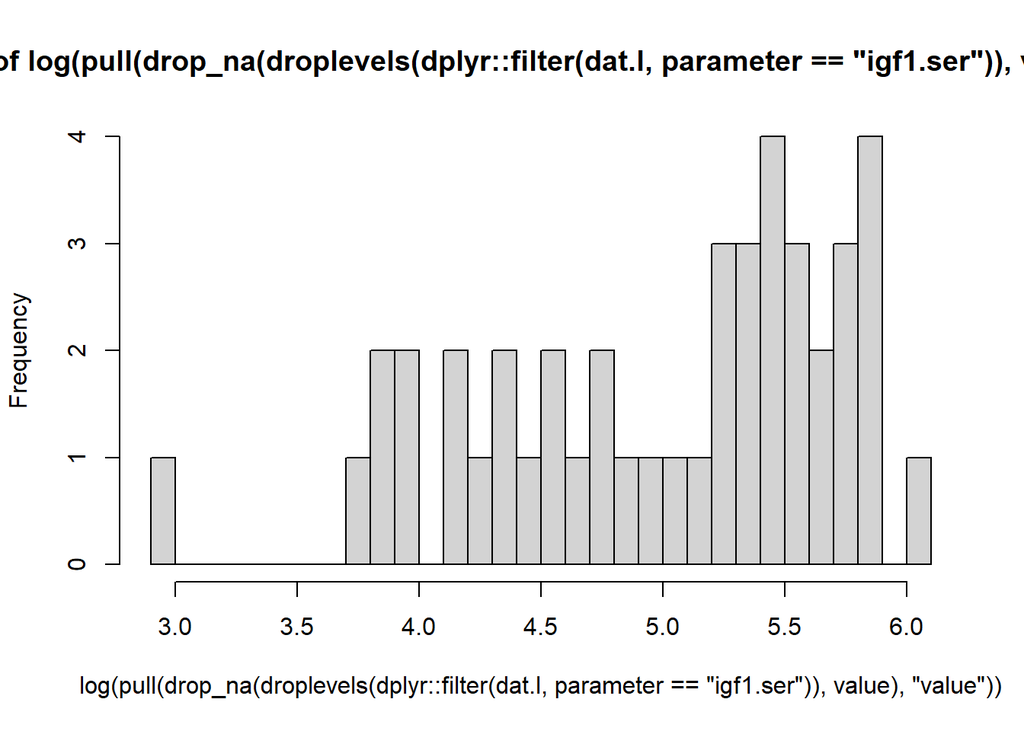

```r
hist(log(dat.l |>
       dplyr::filter(parameter == "igf1.ser") |>
       droplevels() |>
       drop_na(value) |>
       pull("value")),
     breaks = 30)
```

Singularity issues if nested structure defined like `(1 | sow/litter.no)`.

```r
mod.igf1 <- lmerTest::lmer(log(value) ~
                              husbandry +
                              time +
                              # interaction term
                              husbandry : time +
                              # random intercept for sows and for each litter within sow
                              (1 | sow/litter.no),
                            data    = dat.l |>
                              dplyr::filter(parameter == "igf1.ser") |>
                              droplevels() |>
                              drop_na(value),
                            REML    = TRUE,
                            control = contr)
```

```
boundary (singular) fit: see help('isSingular')
```

```r
summary(mod.igf1)
```

```
Linear mixed model fit by REML. t-tests use Satterthwaite's method [
lmerModLmerTest]
Formula: log(value) ~ husbandry + time + husbandry:time + (1 | sow/litter.no)
   Data: drop_na(droplevels(dplyr::filter(dat.l, parameter == "igf1.ser")),
    value)
Control: contr

REML criterion at convergence: 77

Scaled residuals:
     Min       1Q   Median       3Q      Max
-1.90876 -0.52177 -0.03551  0.52631  1.57329

Random effects:
 Groups        Name        Variance  Std.Dev.
 litter.no:sow (Intercept) 2.225e-01 4.717e-01
 sow           (Intercept) 6.468e-17 8.042e-09
 Residual                  1.642e-01 4.052e-01
Number of obs: 44, groups:  litter.no:sow, 22; sow, 15

Fixed effects:
                             Estimate Std. Error      df t value Pr(>|t|)
(Intercept)                    4.8938     0.1966 30.0492  24.887   <2e-16 ***
husbandryecological           -0.5121     0.2663 30.0492  -1.923   0.0640 .
time8dpp                       0.5069     0.1812 20.0000   2.797   0.0111 *
husbandryecological:time8dpp   0.4368     0.2453 20.0000   1.780   0.0902 .
---
Signif. codes:  0 '***' 0.001 '**' 0.01 '*' 0.05 '.' 0.1 ' ' 1

Correlation of Fixed Effects:
            (Intr) hsbndr tm8dpp
hsbndryclgc -0.739
time8dpp    -0.461  0.340
hsbndrycl:8  0.340 -0.461 -0.739
optimizer (bobyqa) convergence code: 0 (OK)
boundary (singular) fit: see help('isSingular')
```

```r
round(drop1(mod.igf1, test = 'Chisq'), 3)
```

```
Single term deletions using Satterthwaite's method:

Model:
log(value) ~ husbandry + time + husbandry:time + (1 | sow/litter.no)
               Sum Sq Mean Sq NumDF DenDF F value Pr(>F)
husbandry:time   0.52    0.52     1    20    3.17   0.09 .
---
Signif. codes:  0 '***' 0.001 '**' 0.01 '*' 0.05 '.' 0.1 ' ' 1
```

Without significant interactions, choose `type = 2`. With significant interactions, choose `type = 3`.

```r
car::Anova(mod.igf1,
           test.statistic = "Chisq",
           type = 2)
```

```
Analysis of Deviance Table (Type II Wald chisquare tests)

Response: log(value)
                 Chisq Df Pr(>Chisq)
husbandry       1.5445  1    0.21395
time           37.2036  1  1.064e-09 ***
husbandry:time  3.1696  1    0.07502 .
---
Signif. codes:  0 '***' 0.001 '**' 0.01 '*' 0.05 '.' 0.1 ' ' 1
```

```r
car::Anova(mod.igf1,
           test.statistic = "F",
           type = 2)
```

```
Analysis of Deviance Table (Type II Wald F tests with Kenward-Roger df)

Response: log(value)
                     F Df Df.res    Pr(>F)
husbandry       1.4352  1 11.177   0.25570
time           37.2036  1 20.000 5.826e-06 ***
husbandry:time  3.1696  1 20.000   0.09022 .
---
Signif. codes:  0 '***' 0.001 '**' 0.01 '*' 0.05 '.' 0.1 ' ' 1
```

## Model diagnostics

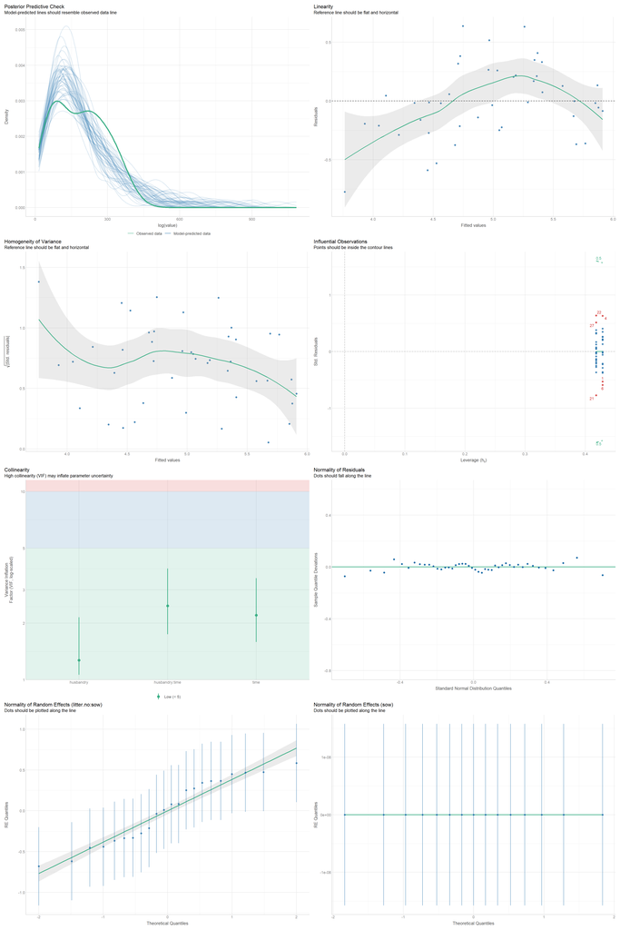

```r
performance::check_model(mod.igf1)
```

## Emmeans & Effect sizes

### Husbandry

Emmeans:

```r
emm <- emmeans(mod.igf1,
        pairwise ~ husbandry,
        data    = dat.l |>
          dplyr::filter(parameter == "igf1.ser") |>
          droplevels() |>
          drop_na(value),
        adjust  = "tukey",
        lmer.df = "satterthwaite",
        type    = "response")
```

```
NOTE: Results may be misleading due to involvement in interactions
```

```r
emm
```

```
$emmeans
 husbandry    response   SE df lower.CL upper.CL
 conventional      172 30.0 20      119      247
 ecological        128 20.4 20       92      179

Results are averaged over the levels of: time
Degrees-of-freedom method: satterthwaite
Confidence level used: 0.95
Intervals are back-transformed from the log scale

$contrasts
 contrast                  ratio    SE df null t.ratio p.value
 conventional / ecological  1.34 0.317 20    1   1.243  0.2283

Results are averaged over the levels of: time
Degrees-of-freedom method: satterthwaite
Tests are performed on the log scale
```

Effect sizes:

```r
eff_size(emm,
         sigma = sigma(mod.igf1),
         edf = df.residual(mod.igf1))
```

```
Since 'object' is a list, we are using the contrasts already present.
```

```
 contrast                    estimate    SE df lower.CL upper.CL
 (conventional - ecological)    0.725 0.589 20   -0.504     1.95

Results are averaged over the levels of: time
sigma used for effect sizes: 0.4052
Degrees-of-freedom method: inherited from satterthwaite when re-gridding
Confidence level used: 0.95
```

### Time point

Emmeans:

```r
emm <- emmeans(mod.igf1,
        pairwise ~ time,
        data    = dat.l |>
          dplyr::filter(parameter == "igf1.ser") |>
          droplevels() |>
          drop_na(value),
        adjust  = "tukey",
        lmer.df = "satterthwaite",
        type    = "response")
```

```
NOTE: Results may be misleading due to involvement in interactions
```

```r
emm
```

```
$emmeans
 time   response   SE   df lower.CL upper.CL
 105dpc      103 13.8 30.1     78.7      136
 8dpp        213 28.4 30.1    162.6      280

Results are averaged over the levels of: husbandry
Degrees-of-freedom method: satterthwaite
Confidence level used: 0.95
Intervals are back-transformed from the log scale

$contrasts
 contrast      ratio     SE df null t.ratio p.value
 105dpc / 8dpp 0.484 0.0594 20    1  -5.912  <.0001

Results are averaged over the levels of: husbandry
Degrees-of-freedom method: satterthwaite
Tests are performed on the log scale
```

Effect sizes:

```r
eff_size(emm,
         sigma = sigma(mod.igf1),
         edf = df.residual(mod.igf1))
```

```
Since 'object' is a list, we are using the contrasts already present.
```

```
 contrast        estimate    SE df lower.CL upper.CL
 (105dpc - 8dpp)    -1.79 0.367 20    -2.56    -1.02

Results are averaged over the levels of: husbandry
sigma used for effect sizes: 0.4052
Degrees-of-freedom method: inherited from satterthwaite when re-gridding
Confidence level used: 0.95
```

### Husbandry:Time point

Emmeans:

```r
emm.igf1_ht <- emmeans(mod.igf1,
                       pairwise ~ husbandry|time,
                       data    = dat.l |>
                         dplyr::filter(parameter == "igf1.ser") |>
                         droplevels() |>
                         drop_na(value),
                       adjust  = "tukey",
                       lmer.df = "satterthwaite",
                       type    = "response")

emm.igf1_ht
```

```
$emmeans
time = 105dpc:
 husbandry    response   SE   df lower.CL upper.CL
 conventional      133 26.2 30.1     89.3      199
 ecological         80 14.4 30.1     55.4      115

time = 8dpp:
 husbandry    response   SE   df lower.CL upper.CL
 conventional      222 43.6 30.1    148.3      331
 ecological        205 36.9 30.1    142.4      296

Degrees-of-freedom method: satterthwaite
Confidence level used: 0.95
Intervals are back-transformed from the log scale

$contrasts
time = 105dpc:
 contrast                  ratio    SE   df null t.ratio p.value
 conventional / ecological  1.67 0.444 30.1    1   1.923  0.0640

time = 8dpp:
 contrast                  ratio    SE   df null t.ratio p.value
 conventional / ecological  1.08 0.287 30.1    1   0.283  0.7793

Degrees-of-freedom method: satterthwaite
Tests are performed on the log scale
```

Effect sizes:

```r
eff_size(emm.igf1_ht,
         sigma = sigma(mod.igf1),
         edf = df.residual(mod.igf1))
```

```
Since 'object' is a list, we are using the contrasts already present.
```

```
time = 105dpc:
 contrast                    estimate    SE   df lower.CL upper.CL
 (conventional - ecological)    1.264 0.673 30.1   -0.111     2.64

time = 8dpp:
 contrast                    estimate    SE   df lower.CL upper.CL
 (conventional - ecological)    0.186 0.657 30.1   -1.157     1.53

sigma used for effect sizes: 0.4052
Degrees-of-freedom method: inherited from satterthwaite when re-gridding
Confidence level used: 0.95
```

### Time point:Husbandry

Emmeans:

```r
emm.igf1_th <- emmeans(mod.igf1,
                       pairwise ~ time|husbandry,
                       data    = dat.l |>
                         dplyr::filter(parameter == "igf1.ser") |>
                         droplevels() |>
                         drop_na(value),
                       adjust  = "tukey",
                       lmer.df = "satterthwaite",
                       type    = "response")

emm.igf1_th
```

```
$emmeans
husbandry = conventional:
 time   response   SE   df lower.CL upper.CL
 105dpc      133 26.2 30.1     89.3      199
 8dpp        222 43.6 30.1    148.3      331

husbandry = ecological:
 time   response   SE   df lower.CL upper.CL
 105dpc       80 14.4 30.1     55.4      115
 8dpp        205 36.9 30.1    142.4      296

Degrees-of-freedom method: satterthwaite
Confidence level used: 0.95
Intervals are back-transformed from the log scale

$contrasts
husbandry = conventional:
 contrast      ratio     SE df null t.ratio p.value
 105dpc / 8dpp 0.602 0.1090 20    1  -2.797  0.0111

husbandry = ecological:
 contrast      ratio     SE df null t.ratio p.value
 105dpc / 8dpp 0.389 0.0644 20    1  -5.705  <.0001

Degrees-of-freedom method: satterthwaite
Tests are performed on the log scale
```

Effect sizes:

```r
eff_size(emm.igf1_th,
         sigma = sigma(mod.igf1),
         edf = df.residual(mod.igf1))
```

```
Since 'object' is a list, we are using the contrasts already present.
```

```
husbandry = conventional:
 contrast        estimate   SE df lower.CL upper.CL
 (105dpc - 8dpp)    -1.25 0.47 20    -2.23    -0.27

husbandry = ecological:
 contrast        estimate   SE df lower.CL upper.CL
 (105dpc - 8dpp)    -2.33 0.49 20    -3.35    -1.31

sigma used for effect sizes: 0.4052
Degrees-of-freedom method: inherited from satterthwaite when re-gridding
Confidence level used: 0.95
```

## Plot

Add significant contrasts to the plot:

```r
contr.igf1_th <- contrast(emm.igf1_th, method = "pairwise") |>
  as.data.frame() |>
  as_tibble() |>
  mutate(p.label = dplyr::case_when(
    p.value < 0.001 ~ "p < 0.001",
    p.value < 0.05  ~ sprintf("p = %.3f", p.value),
    TRUE            ~ NA_character_)) |>
  # for brackets
  mutate(
    group1 = "105dpc",
    group2 = "8dpp") |>
  mutate(
    xmin = case_when(
      husbandry == "conventional" ~ 0.875,
      husbandry == "ecological"   ~ 1.125
    ),
    xmax = case_when(
      husbandry == "conventional" ~ 1.875,
      husbandry == "ecological"   ~ 2.125)) |>
  mutate(y.position = 405) |>
  # only significant results
  dplyr::filter(!is.na(p.label))
```

```r
plot.igf1 <- dat.l  |>
  dplyr::filter(parameter == "igf1.ser") |>
  droplevels() |>
  drop_na(value) |>
  # plot
  mutate(jit = jitter(as.numeric(time), 0.3)) |>
  ggplot(aes(y   = value)) +
  geom_boxplot(aes(x   = time,
                   fill = husbandry),
               col = "black",
               outlier.shape = NA, width = 0.5) +
  geom_jitter(aes(x   = time,
                  fill = husbandry),
              col = "black",
              position = position_jitterdodge(jitter.width  = 0.15,
                                              dodge.width   = 0.5),
              size = 2, alpha = 0.7,
              show.legend = FALSE) +
  ggpubr::stat_pvalue_manual(
    contr.igf1_th,
    inherit.aes = FALSE,
    label = "p.label",
    xmin = "xmin",
    xmax = "xmax",
    y.position = "y.position",
    step.increase = 0.1,
    size = 14/.pt,
    bracket.size = 0.8,
    tip.length = 0.03,
    position = position_dodge(width = 0.5)) +
  scale_fill_manual(labels = c("Conventional",
                               "Ecological"),
                    values = c("#FFA040", "#008000")) +
  scale_y_continuous(breaks = seq(0, 410, 100),
                     minor_breaks = seq(0, 405, by = 20),
                     expand = expansion(mult = c(0.05, 0.1))) +
  # important to define limits of the coord system not of the y-axis
  coord_cartesian(ylim = c(0, 410), clip = "off") +
  scale_x_discrete(labels= c("105dpc", "8dpp")) +
  labs(x = "",
       y = "IGF1 (serum) [ng/ml]",
       fill = "Husbandry") +
  my_theme +
  theme(legend.position = "top") +
  guides(y = guide_axis(minor.ticks = TRUE),
         fill = guide_legend(override.aes = list(linetype = 0, size  = 5)))
```

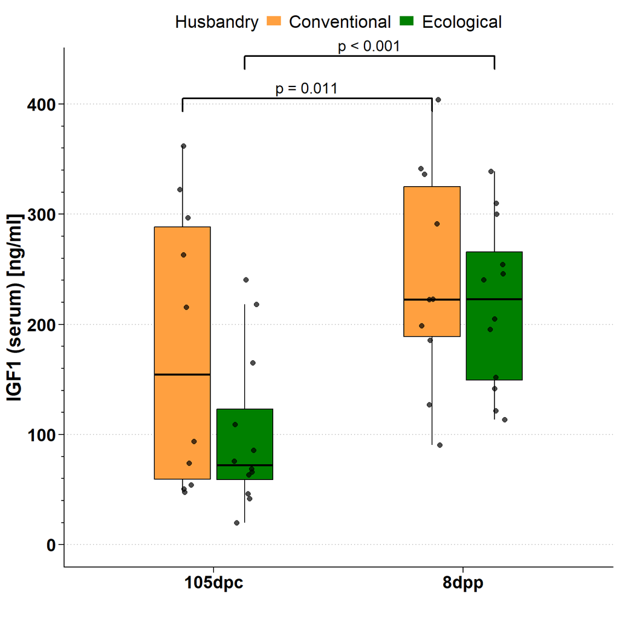

```r
plot.igf1
```

# IGF2 (serum)

## Model

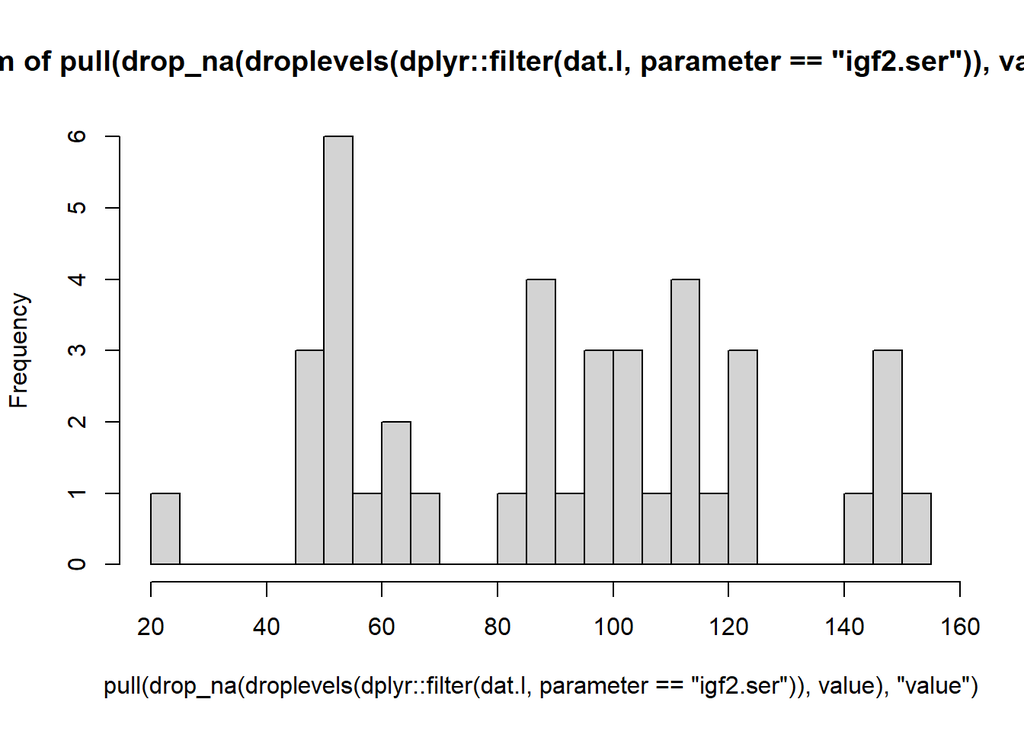

```r
hist(dat.l |>
       dplyr::filter(parameter == "igf2.ser") |>
       droplevels() |>
       drop_na(value) |>
       pull("value"),
     breaks = 30)
```

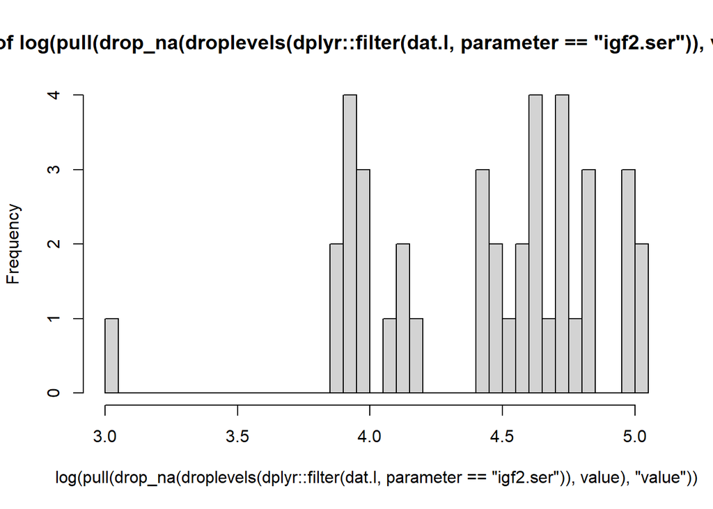

```r
hist(log(dat.l |>
       dplyr::filter(parameter == "igf2.ser") |>
       droplevels() |>
       drop_na(value) |>
       pull("value")),
     breaks = 30)
```

Singularity issues if nested structure defined like `(1 | sow/litter.no)`.

```r
mod.igf2 <- lmerTest::lmer(log(value) ~
                              husbandry +
                              time +
                              # interaction term
                              husbandry : time +
                              # random intercept for sows and for each litter within sow
                              (1 | sow/litter.no),
                            data    = dat.l |>
                              dplyr::filter(parameter == "igf2.ser") |>
                              droplevels() |>
                              drop_na(value),
                            REML    = TRUE,
                            control = contr)
```

```
boundary (singular) fit: see help('isSingular')
```

```r
summary(mod.igf2)
```

```
Linear mixed model fit by REML. t-tests use Satterthwaite's method [
lmerModLmerTest]
Formula: log(value) ~ husbandry + time + husbandry:time + (1 | sow/litter.no)
   Data: drop_na(droplevels(dplyr::filter(dat.l, parameter == "igf2.ser")),
    value)
Control: contr

REML criterion at convergence: 15.3

Scaled residuals:
    Min      1Q  Median      3Q     Max
-3.3607 -0.5221  0.0581  0.4752  1.6754

Random effects:
 Groups        Name        Variance  Std.Dev.
 litter.no:sow (Intercept) 1.265e-02 1.125e-01
 sow           (Intercept) 5.401e-17 7.349e-09
 Residual                  5.793e-02 2.407e-01
Number of obs: 40, groups:  litter.no:sow, 20; sow, 14

Fixed effects:
                             Estimate Std. Error       df t value Pr(>|t|)
(Intercept)                   4.26837    0.08401 34.87974  50.808  < 2e-16 ***
husbandryecological          -0.33300    0.11881 34.87974  -2.803 0.008215 **
time8dpp                      0.42980    0.10764 18.00000   3.993 0.000853 ***
husbandryecological:time8dpp  0.43848    0.15222 18.00000   2.881 0.009955 **
---
Signif. codes:  0 '***' 0.001 '**' 0.01 '*' 0.05 '.' 0.1 ' ' 1

Correlation of Fixed Effects:
            (Intr) hsbndr tm8dpp
hsbndryclgc -0.707
time8dpp    -0.641  0.453
hsbndrycl:8  0.453 -0.641 -0.707
optimizer (bobyqa) convergence code: 0 (OK)
boundary (singular) fit: see help('isSingular')
```

```r
round(drop1(mod.igf2, test = 'Chisq'), 3)
```

```
Single term deletions using Satterthwaite's method:

Model:
log(value) ~ husbandry + time + husbandry:time + (1 | sow/litter.no)
               Sum Sq Mean Sq NumDF DenDF F value Pr(>F)
husbandry:time  0.481   0.481     1    18   8.298   0.01 **
---
Signif. codes:  0 '***' 0.001 '**' 0.01 '*' 0.05 '.' 0.1 ' ' 1
```

```r
car::Anova(mod.igf2,
           test.statistic = "Chisq",
           type = 2)
```

```
Analysis of Deviance Table (Type II Wald chisquare tests)

Response: log(value)
                 Chisq Df Pr(>Chisq)
husbandry       1.5551  1    0.21239
time           72.7197  1    < 2e-16 ***
husbandry:time  8.2975  1    0.00397 **
---
Signif. codes:  0 '***' 0.001 '**' 0.01 '*' 0.05 '.' 0.1 ' ' 1
```

```r
car::Anova(mod.igf2,
           test.statistic = "F",
           type = 2)
```

```
Analysis of Deviance Table (Type II Wald F tests with Kenward-Roger df)

Response: log(value)
                     F Df Df.res    Pr(>F)
husbandry       1.4218  1 10.105  0.260359
time           72.7197  1 18.000 9.755e-08 ***
husbandry:time  8.2975  1 18.000  0.009955 **
---
Signif. codes:  0 '***' 0.001 '**' 0.01 '*' 0.05 '.' 0.1 ' ' 1
```

## Model diagnostics

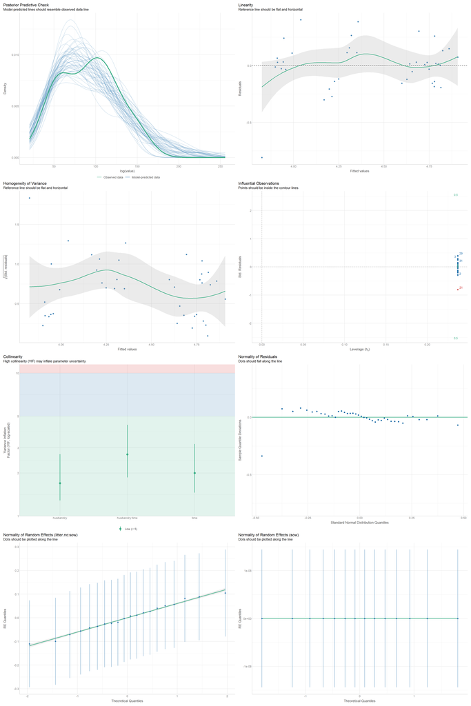

```r
performance::check_model(mod.igf2)
```

## Emmeans & Effect sizes

### Husbandry

Emmeans:

```r
emm <- emmeans(mod.igf2,
        pairwise ~ husbandry,
        data    = dat.l |>
          dplyr::filter(parameter == "igf2.ser") |>
          droplevels() |>
          drop_na(value),
        adjust  = "tukey",
        lmer.df = "satterthwaite",
        type    = "response")
```

```
NOTE: Results may be misleading due to involvement in interactions
```

```r
emm
```

```
$emmeans
 husbandry    response   SE df lower.CL upper.CL
 conventional     88.5 5.71 18     77.3    101.4
 ecological       79.0 5.10 18     69.0     90.5

Results are averaged over the levels of: time
Degrees-of-freedom method: satterthwaite
Confidence level used: 0.95
Intervals are back-transformed from the log scale

$contrasts
 contrast                  ratio    SE df null t.ratio p.value
 conventional / ecological  1.12 0.102 18    1   1.247  0.2284

Results are averaged over the levels of: time
Degrees-of-freedom method: satterthwaite
Tests are performed on the log scale
```

Effect sizes:

```r
eff_size(emm,
         sigma = sigma(mod.igf2),
         edf = df.residual(mod.igf2))
```

```
Since 'object' is a list, we are using the contrasts already present.
```

```
 contrast                    estimate    SE df lower.CL upper.CL
 (conventional - ecological)    0.473 0.383 18   -0.333     1.28

Results are averaged over the levels of: time
sigma used for effect sizes: 0.2407
Degrees-of-freedom method: inherited from satterthwaite when re-gridding
Confidence level used: 0.95
```

### Time point

Emmeans:

```r
emm <- emmeans(mod.igf2,
        pairwise ~ time,
        data    = dat.l |>
          dplyr::filter(parameter == "igf2.ser") |>
          droplevels() |>
          drop_na(value),
        adjust  = "tukey",
        lmer.df = "satterthwaite",
        type    = "response")
```

```
NOTE: Results may be misleading due to involvement in interactions
```

```r
emm
```

```
$emmeans
 time   response   SE   df lower.CL upper.CL
 105dpc     60.5 3.59 34.9     53.6     68.2
 8dpp      115.7 6.87 34.9    102.5    130.5

Results are averaged over the levels of: husbandry
Degrees-of-freedom method: satterthwaite
Confidence level used: 0.95
Intervals are back-transformed from the log scale

$contrasts
 contrast      ratio     SE df null t.ratio p.value
 105dpc / 8dpp 0.523 0.0398 18    1  -8.528  <.0001

Results are averaged over the levels of: husbandry
Degrees-of-freedom method: satterthwaite
Tests are performed on the log scale
```

Effect sizes:

```r
eff_size(emm,
         sigma = sigma(mod.igf2),
         edf = df.residual(mod.igf2))
```

```
Since 'object' is a list, we are using the contrasts already present.
```

```
 contrast        estimate    SE df lower.CL upper.CL
 (105dpc - 8dpp)     -2.7 0.458 18    -3.66    -1.73

Results are averaged over the levels of: husbandry
sigma used for effect sizes: 0.2407
Degrees-of-freedom method: inherited from satterthwaite when re-gridding
Confidence level used: 0.95
```

### Husbandry:Time point

Emmeans:

```r
emm.igf2_ht <- emmeans(mod.igf2,
                       pairwise ~ husbandry|time,
                       data    = dat.l |>
                         dplyr::filter(parameter == "igf2.ser") |>
                         droplevels() |>
                         drop_na(value),
                       adjust  = "tukey",
                       lmer.df = "satterthwaite",
                       type    = "response")

emm.igf2_ht
```

```
$emmeans
time = 105dpc:
 husbandry    response    SE   df lower.CL upper.CL
 conventional     71.4  6.00 34.9     60.2     84.7
 ecological       51.2  4.30 34.9     43.2     60.7

time = 8dpp:
 husbandry    response    SE   df lower.CL upper.CL
 conventional    109.7  9.22 34.9     92.5    130.2
 ecological      122.0 10.20 34.9    102.8    144.6

Degrees-of-freedom method: satterthwaite
Confidence level used: 0.95
Intervals are back-transformed from the log scale

$contrasts
time = 105dpc:
 contrast                  ratio    SE   df null t.ratio p.value
 conventional / ecological   1.4 0.166 34.9    1   2.803  0.0082

time = 8dpp:
 contrast                  ratio    SE   df null t.ratio p.value
 conventional / ecological   0.9 0.107 34.9    1  -0.888  0.3807

Degrees-of-freedom method: satterthwaite
Tests are performed on the log scale
```

Effect sizes:

```r
eff_size(emm.igf2_ht,
         sigma = sigma(mod.igf2),
         edf = df.residual(mod.igf2))
```

```
Since 'object' is a list, we are using the contrasts already present.
```

```
time = 105dpc:
 contrast                    estimate    SE   df lower.CL upper.CL
 (conventional - ecological)    1.384 0.522 34.9    0.323     2.44

time = 8dpp:
 contrast                    estimate    SE   df lower.CL upper.CL
 (conventional - ecological)   -0.438 0.497 34.9   -1.446     0.57

sigma used for effect sizes: 0.2407
Degrees-of-freedom method: inherited from satterthwaite when re-gridding
Confidence level used: 0.95
```

### Time point:Husbandry

Emmeans:

```r
emm.igf2_th <- emmeans(mod.igf2,
                       pairwise ~ time|husbandry,
                       data    = dat.l |>
                         dplyr::filter(parameter == "igf2.ser") |>
                         droplevels() |>
                         drop_na(value),
                       adjust  = "tukey",
                       lmer.df = "satterthwaite",
                       type    = "response")

emm.igf2_th
```

```
$emmeans
husbandry = conventional:
 time   response    SE   df lower.CL upper.CL
 105dpc     71.4  6.00 34.9     60.2     84.7
 8dpp      109.7  9.22 34.9     92.5    130.2

husbandry = ecological:
 time   response    SE   df lower.CL upper.CL
 105dpc     51.2  4.30 34.9     43.2     60.7
 8dpp      122.0 10.20 34.9    102.8    144.6

Degrees-of-freedom method: satterthwaite
Confidence level used: 0.95
Intervals are back-transformed from the log scale

$contrasts
husbandry = conventional:
 contrast      ratio     SE df null t.ratio p.value
 105dpc / 8dpp 0.651 0.0700 18    1  -3.993  0.0009

husbandry = ecological:
 contrast      ratio     SE df null t.ratio p.value
 105dpc / 8dpp 0.420 0.0452 18    1  -8.067  <.0001

Degrees-of-freedom method: satterthwaite
Tests are performed on the log scale
```

Effect sizes:

```r
eff_size(emm.igf2_th,
         sigma = sigma(mod.igf2),
         edf = df.residual(mod.igf2))
```

```
Since 'object' is a list, we are using the contrasts already present.
```

```
husbandry = conventional:
 contrast        estimate    SE df lower.CL upper.CL
 (105dpc - 8dpp)    -1.79 0.498 18    -2.83   -0.739

husbandry = ecological:
 contrast        estimate    SE df lower.CL upper.CL
 (105dpc - 8dpp)    -3.61 0.630 18    -4.93   -2.284

sigma used for effect sizes: 0.2407
Degrees-of-freedom method: inherited from satterthwaite when re-gridding
Confidence level used: 0.95
```

## Plot

Add significant contrasts to the plot:

```r
contr.igf2_ht <- contrast(emm.igf2_ht, method = "pairwise") |>
  as.data.frame() |>
  as_tibble() |>
  mutate(p.label = dplyr::case_when(
    p.value < 0.001 ~ "p < 0.001",
    p.value < 0.05  ~ sprintf("p = %.3f", p.value),
    TRUE            ~ NA_character_)) |>
  # for brackets
  mutate(
    group1 = "conventional",
    group2 = "ecological") |>
  mutate(
    x = as.numeric(time),
    xmin = x - 0.25 * 0.5,
    xmax = x + 0.25 * 0.5) |>
  mutate(y.position = 130) |>
  # only significant results
  dplyr::filter(!is.na(p.label))
```

```r
contr.igf2_th <- contrast(emm.igf2_th, method = "pairwise") |>
  as.data.frame() |>
  as_tibble() |>
  mutate(p.label = dplyr::case_when(
    p.value < 0.001 ~ "p < 0.001",
    p.value < 0.05  ~ sprintf("p = %.3f", p.value),
    TRUE            ~ NA_character_)) |>
  # for brackets
  mutate(
    group1 = "105dpc",
    group2 = "8dpp") |>
  mutate(
    xmin = case_when(
      husbandry == "conventional" ~ 0.875,
      husbandry == "ecological"   ~ 1.125
    ),
    xmax = case_when(
      husbandry == "conventional" ~ 1.875,
      husbandry == "ecological"   ~ 2.125)) |>
  mutate(y.position = 150) |>
  # only significant results
  dplyr::filter(!is.na(p.label))
```

```r
plot.igf2 <- dat.l  |>
  dplyr::filter(parameter == "igf2.ser") |>
  droplevels() |>
  drop_na(value) |>
  # plot
  mutate(jit = jitter(as.numeric(time), 0.3)) |>
  ggplot(aes(y   = value)) +
  geom_boxplot(aes(x   = time,
                   fill = husbandry),
               col = "black",
               outlier.shape = NA, width = 0.5) +
  geom_jitter(aes(x   = time,
                  fill = husbandry),
              col = "black",
              position = position_jitterdodge(jitter.width  = 0.15,
                                              dodge.width   = 0.5),
              size = 2, alpha = 0.7,
              show.legend = FALSE) +
  ggpubr::stat_pvalue_manual(
    contr.igf2_ht,
    inherit.aes = FALSE,
    label = "p.label",
    xmin = "xmin",
    xmax = "xmax",
    y.position = "y.position",
    size = 14/.pt,
    bracket.size = 0.8,
    tip.length = 0.03,
    position = position_dodge(width = 0.5)) +
  ggpubr::stat_pvalue_manual(
    contr.igf2_th,
    inherit.aes = FALSE,
    label = "p.label",
    xmin = "xmin",
    xmax = "xmax",
    y.position = "y.position",
    step.increase = 0.1,
    size = 14/.pt,
    bracket.size = 0.8,
    tip.length = 0.03,
    position = position_dodge(width = 0.5)) +
  scale_fill_manual(labels = c("Conventional",
                               "Ecological"),
                    values = c("#FFA040", "#008000")) +
  scale_y_continuous(breaks = seq(0, 160, 50),
                     minor_breaks = seq(0, 160, by = 10),
                     expand = expansion(mult = c(0.05, 0.1))) +
  # important to define limits of the coord system not of the y-axis
  coord_cartesian(ylim = c(0, 160), clip = "off") +
  scale_x_discrete(labels= c("105dpc", "8dpp")) +
  labs(x = "",
       y = "IGF2 (serum) [ng/ml]",
       fill = "Husbandry") +
  guides(y = guide_axis(minor.ticks = TRUE),
         fill = guide_legend(override.aes = list(linetype = 0, size  = 5))) +
  my_theme +
  theme(legend.position = "top") +
  guides(y = guide_axis(minor.ticks = TRUE),
         fill = guide_legend(override.aes = list(linetype = 0, size  = 5)))
```

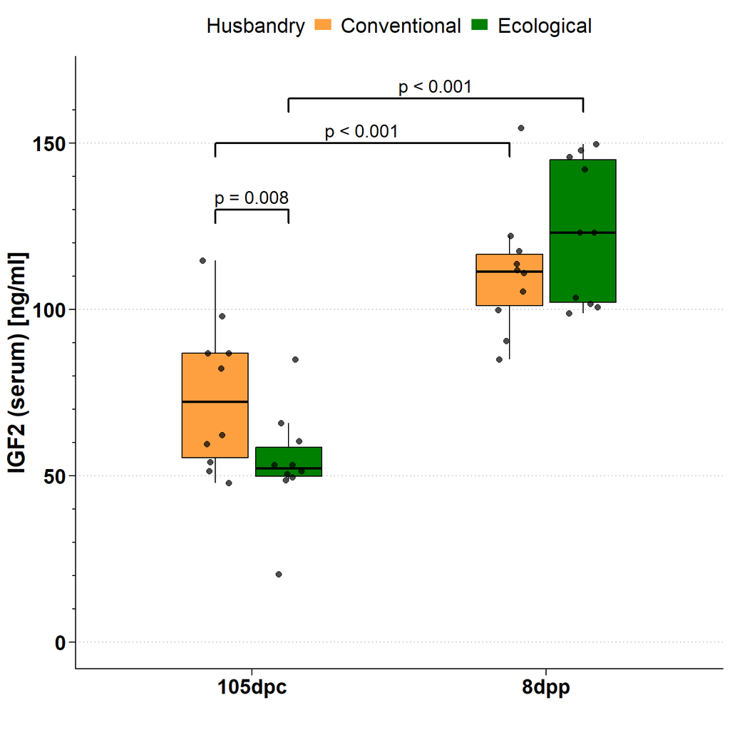

```r
plot.igf2
```

# Combined plots: Figure 3

```r
# Combine plots with a designated area for the legend
combined <- (plot.cort1 +
             plot.cort2 +
             plot.bioact) +
  plot_layout(guides = "collect") +
  plot_annotation(tag_levels = 'A') &
  theme(plot.tag = element_text(face = "bold", size = 20),
        legend.position = "bottom",
        legend.direction = "horizontal")
```

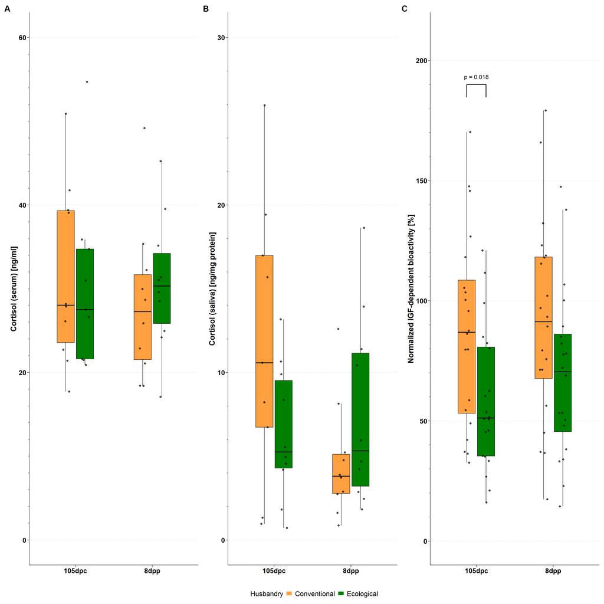

```r
combined
```

```r
png("./plots/figure3.png",
     width = 300, height = 200, units = "mm",
     pointsize = 10, res = 600)

combined

dev.off()
```

# Combined plots: Figure 4

```r
# Combine plots with a designated area for the legend
combined <- (plot.igf1 +
             plot.igf2) +
  plot_layout(guides = "collect") +
  plot_annotation(tag_levels = 'A') &
  theme(plot.tag = element_text(face = "bold", size = 20),
        legend.position = "bottom",
        legend.direction = "horizontal")
```

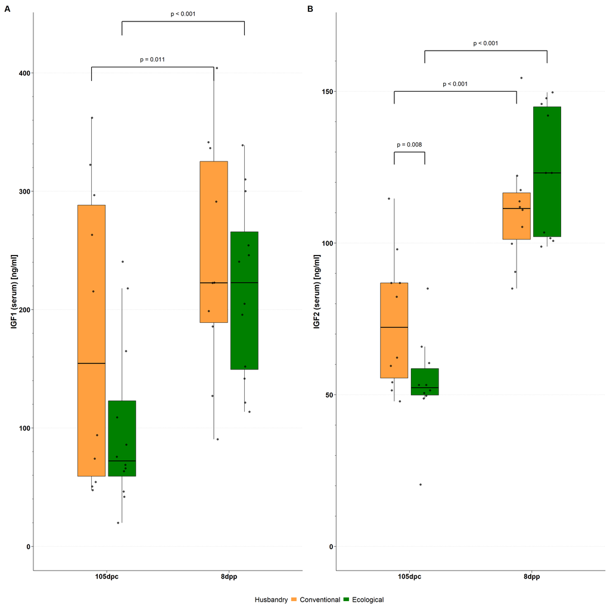

```r
combined
```

```r
png("./plots/figure4.png",
     width = 300, height = 200, units = "mm",
     pointsize = 10, res = 600)

combined
dev.off()
```

# Litter numbers

```r
plot.bio.li <- dat.w  |>
  # plot
  mutate(jit = jitter(as.numeric(litter.no), 0.3)) |>
  ggplot(aes(y   = bioact.ser.105dpc)) +
  geom_boxplot(aes(x   = litter.no,
                   fill = husbandry),
               col = "black",
               outlier.shape = NA, width = 0.5) +
  geom_jitter(aes(x   = litter.no,
                  fill = husbandry),
              col = "black",
              position = position_jitterdodge(jitter.width  = 0.15,
                                              dodge.width   = 0.5),
              size = 2, alpha = 0.7,
              show.legend = FALSE) +
  scale_fill_manual(labels = c("Conventional",
                               "Ecological"),
                    values = c("#FFA040", "#008000")) +
  scale_y_continuous(lim = c(0, 200),
                     breaks = seq(0, 200, 50),
                     minor_breaks = seq(0, 200, by = 10) ) +
  scale_x_discrete(labels= c("1st", "2nd", "3rd")) +
  labs(x = "Litter number",
       y = "IGF bioactivity 105dpc [ng/ml]",
       fill = "Husbandry") +
  my_theme +
  theme(legend.position = "bottom") +
  guides(y = guide_axis(minor.ticks = TRUE),
         fill = guide_legend(override.aes = list(linetype = 0, size  = 5)))
```

```r
plot.lbw.li <- dat.w  |>
  # plot
  mutate(jit = jitter(as.numeric(litter.no), 0.3)) |>
  ggplot(aes(y   = prop.lbw)) +
  geom_boxplot(aes(x   = litter.no,
                   fill = husbandry),
               col = "black",
               outlier.shape = NA, width = 0.5) +
  geom_jitter(aes(x   = litter.no,
                  fill = husbandry),
              col = "black",
              position = position_jitterdodge(jitter.width  = 0.15,
                                              dodge.width   = 0.5),
              size = 2, alpha = 0.7,
              show.legend = FALSE) +
  scale_fill_manual(labels = c("Conventional",
                               "Ecological"),
                    values = c("#FFA040", "#008000")) +
  scale_y_continuous(lim = c(0, 85),
                     breaks = seq(0, 85, 20),
                     minor_breaks = seq(0, 80, by = 5) ) +
  scale_x_discrete(labels= c("1st", "2nd", "3rd")) +
  labs(x = "Litter number",
       y = "Proportion LBW [%]",
       fill = "Husbandry") +
  my_theme +
  theme(legend.position = "bottom") +
  guides(y = guide_axis(minor.ticks = TRUE),
         fill = guide_legend(override.aes = list(linetype = 0, size  = 5)))
```

# Combined plots

```r
# Combine plots with a designated area for the legend
combined <- (plot.bio.li +
             plot.lbw.li) +
  plot_layout(guides = "collect") +
  plot_annotation(tag_levels = 'A') &
  theme(plot.tag = element_text(face = "bold", size = 20),
        legend.position = "bottom")
```

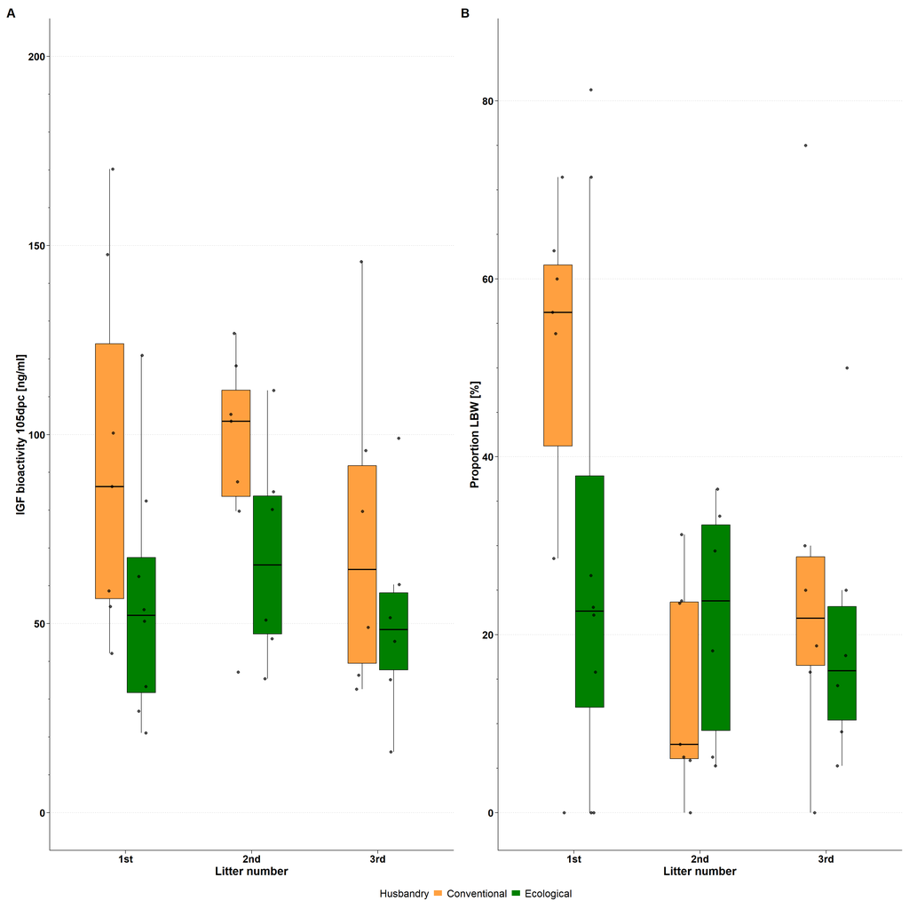

```r
combined
```

# IGFBP2 (serum)

## Model

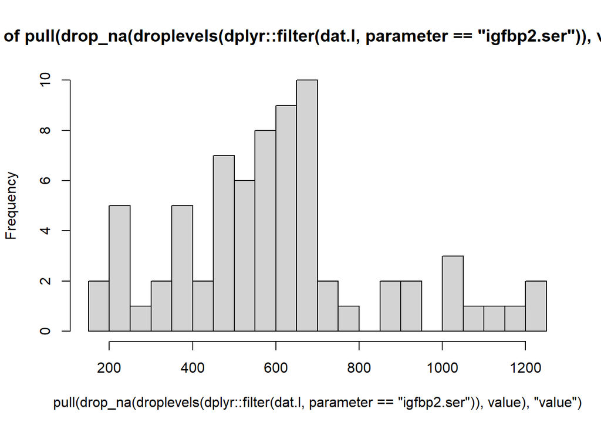

```r
hist(dat.l |>
       dplyr::filter(parameter == "igfbp2.ser") |>
       droplevels() |>
       drop_na(value) |>
       pull("value"),
     breaks = 30)
```

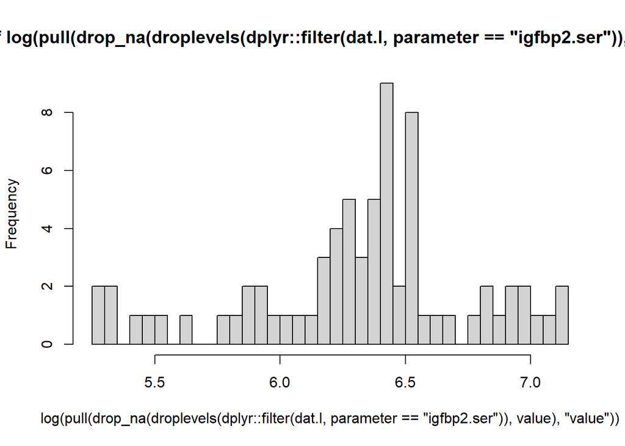

```r
hist(log(dat.l |>
         dplyr::filter(parameter == "igfbp2.ser") |>
         droplevels() |>
         drop_na(value) |>
         pull("value")),
     breaks = 30)
```

Singularity issues if nested structure defined like `(1 | sow/litter.no)`.

```r
mod.igfbp2 <- lmerTest::lmer(log(value) ~
                               husbandry +
                               time +
                               # interaction term
                               husbandry : time +
                               # random intercept for sows and for each litter within sow
                               (1 | sow/litter.no),
                             data    = dat.l |>
                               dplyr::filter(parameter == "igfbp2.ser") |>
                               droplevels() |>
                               drop_na(value),
                             REML    = TRUE,
                             control = contr)
```

```r
summary(mod.igfbp2)
```

```
Linear mixed model fit by REML. t-tests use Satterthwaite's method [
lmerModLmerTest]
Formula: log(value) ~ husbandry + time + husbandry:time + (1 | sow/litter.no)
   Data: drop_na(droplevels(dplyr::filter(dat.l, parameter == "igfbp2.ser")),
    value)
Control: contr

REML criterion at convergence: 63.3

Scaled residuals:
     Min       1Q   Median       3Q      Max
-1.80571 -0.56601  0.02105  0.51087  1.84289

Random effects:
 Groups        Name        Variance Std.Dev.
 litter.no:sow (Intercept) 0.07463  0.2732
 sow           (Intercept) 0.04330  0.2081
 Residual                  0.05864  0.2422
Number of obs: 72, groups:  litter.no:sow, 36; sow, 15

Fixed effects:
                             Estimate Std. Error       df t value Pr(>|t|)
(Intercept)                   6.51548    0.11794 14.52980  55.243   <2e-16 ***
husbandryecological          -0.46275    0.16544 15.40369  -2.797   0.0133 *
time8dpp                     -0.03649    0.08072 34.00000  -0.452   0.6541
husbandryecological:time8dpp  0.13669    0.11416 34.00000   1.197   0.2394
---
Signif. codes:  0 '***' 0.001 '**' 0.01 '*' 0.05 '.' 0.1 ' ' 1

Correlation of Fixed Effects:
            (Intr) hsbndr tm8dpp
hsbndryclgc -0.713
time8dpp    -0.342  0.244
hsbndrycl:8  0.242 -0.345 -0.707
```

```r
round(drop1(mod.igfbp2, test = 'Chisq'), 3)
```

```
Single term deletions using Satterthwaite's method:

Model:
log(value) ~ husbandry + time + husbandry:time + (1 | sow/litter.no)
               Sum Sq Mean Sq NumDF DenDF F value Pr(>F)
husbandry:time  0.084   0.084     1    34   1.434  0.239
```

Without significant interactions, choose `type = 2`. With significant interactions, choose `type = 3`.

```r
car::Anova(mod.igfbp2,
           test.statistic = "Chisq",
           type = 2)
```

```
Analysis of Deviance Table (Type II Wald chisquare tests)

Response: log(value)
                Chisq Df Pr(>Chisq)
husbandry      6.4509  1    0.01109 *
time           0.3114  1    0.57680
husbandry:time 1.4337  1    0.23116
---
Signif. codes:  0 '***' 0.001 '**' 0.01 '*' 0.05 '.' 0.1 ' ' 1
```

```r
car::Anova(mod.igfbp2,
           test.statistic = "F",
           type = 2)
```

```
Analysis of Deviance Table (Type II Wald F tests with Kenward-Roger df)

Response: log(value)
                    F Df Df.res  Pr(>F)
husbandry      6.3339  1  12.02 0.02704 *
time           0.3114  1  34.00 0.58045
husbandry:time 1.4337  1  34.00 0.23945
---
Signif. codes:  0 '***' 0.001 '**' 0.01 '*' 0.05 '.' 0.1 ' ' 1
```

## Model diagnostics

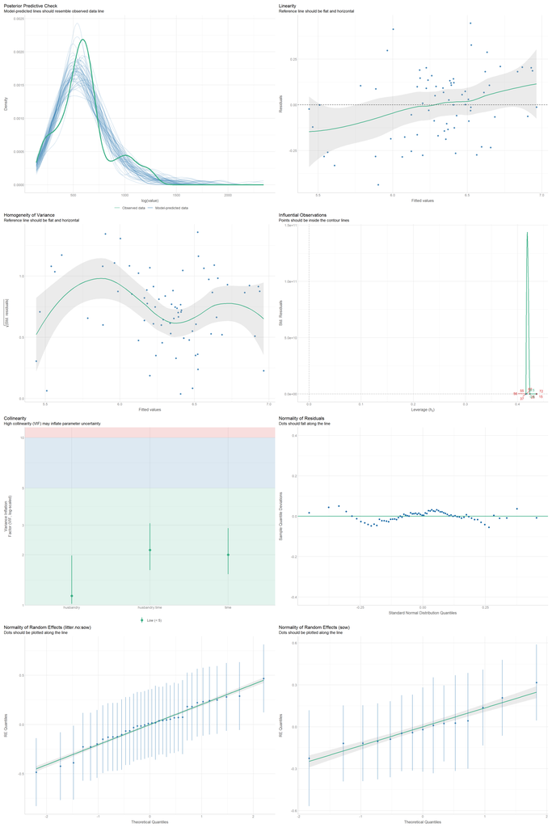

```r
performance::check_model(mod.igfbp2)
```

## Emmeans & Effect sizes

### Husbandry

Emmeans:

```r
emm <- emmeans(mod.igfbp2,
        pairwise ~ husbandry,
        data    = dat.l |>
          dplyr::filter(parameter == "igfbp2.ser") |>
          droplevels() |>
          drop_na(value),
        adjust  = "tukey",
        lmer.df = "satterthwaite",
        type    = "response")
```

```
NOTE: Results may be misleading due to involvement in interactions
```

```r
emm
```

```
$emmeans
 husbandry    response   SE   df lower.CL upper.CL
 conventional      663 73.5 11.4      520      846
 ecological        447 48.6 12.7      353      566

Results are averaged over the levels of: time
Degrees-of-freedom method: satterthwaite
Confidence level used: 0.95
Intervals are back-transformed from the log scale

$contrasts
 contrast                  ratio   SE df null t.ratio p.value
 conventional / ecological  1.48 0.23 12    1   2.540  0.0259

Results are averaged over the levels of: time
Degrees-of-freedom method: satterthwaite
Tests are performed on the log scale
```

Effect sizes:

```r
eff_size(emm,
         sigma = sigma(mod.igfbp2),
         edf = df.residual(mod.igfbp2))
```

```
Since 'object' is a list, we are using the contrasts already present.
```

```
 contrast                    estimate    SE df lower.CL upper.CL
 (conventional - ecological)     1.63 0.657 12    0.198     3.06

Results are averaged over the levels of: time
sigma used for effect sizes: 0.2422
Degrees-of-freedom method: inherited from satterthwaite when re-gridding
Confidence level used: 0.95
```

### Time point

Emmeans:

```r
emm <- emmeans(mod.igfbp2,
        pairwise ~ time,
        data    = dat.l |>
          dplyr::filter(parameter == "igfbp2.ser") |>
          droplevels() |>
          drop_na(value),
        adjust  = "tukey",
        lmer.df = "satterthwaite",
        type    = "response")
```

```
NOTE: Results may be misleading due to involvement in interactions
```

```r
emm
```

```
$emmeans
 time   response   SE   df lower.CL upper.CL
 105dpc      536 44.3 15.4      450      639
 8dpp        553 45.8 15.4      464      660

Results are averaged over the levels of: husbandry
Degrees-of-freedom method: satterthwaite
Confidence level used: 0.95
Intervals are back-transformed from the log scale

$contrasts
 contrast      ratio     SE df null t.ratio p.value
 105dpc / 8dpp 0.969 0.0553 34    1  -0.558  0.5805

Results are averaged over the levels of: husbandry
Degrees-of-freedom method: satterthwaite
Tests are performed on the log scale
```

Effect sizes:

```r
eff_size(emm,
         sigma = sigma(mod.igfbp2),
         edf = df.residual(mod.igfbp2))
```

```
Since 'object' is a list, we are using the contrasts already present.
```

```
 contrast        estimate    SE df lower.CL upper.CL
 (105dpc - 8dpp)   -0.132 0.236 34   -0.611    0.348

Results are averaged over the levels of: husbandry
sigma used for effect sizes: 0.2422
Degrees-of-freedom method: inherited from satterthwaite when re-gridding
Confidence level used: 0.95
```

### Husbandry:Time point

Emmeans:

```r
emm.igfbp2_ht <- emmeans(mod.igfbp2,
                         pairwise ~ husbandry|time,
                         data    = dat.l |>
                           dplyr::filter(parameter == "igfbp2.ser") |>
                           droplevels() |>
                           drop_na(value),
                         adjust  = "tukey",
                         lmer.df = "satterthwaite",
                         type    = "response")

emm.igfbp2_ht
```

```
$emmeans
time = 105dpc:
 husbandry    response   SE   df lower.CL upper.CL
 conventional      676 79.7 14.5      525      869
 ecological        425 49.3 16.4      333      544

time = 8dpp:
 husbandry    response   SE   df lower.CL upper.CL
 conventional      651 76.8 14.5      506      838
 ecological        470 54.5 16.4      368      601

Degrees-of-freedom method: satterthwaite
Confidence level used: 0.95
Intervals are back-transformed from the log scale

$contrasts
time = 105dpc:
 contrast                  ratio    SE   df null t.ratio p.value
 conventional / ecological  1.59 0.263 15.4    1   2.797  0.0133

time = 8dpp:
 contrast                  ratio    SE   df null t.ratio p.value
 conventional / ecological  1.39 0.229 15.4    1   1.971  0.0670

Degrees-of-freedom method: satterthwaite
Tests are performed on the log scale
```

Effect sizes:

```r
eff_size(emm.igfbp2_ht,
         sigma = sigma(mod.igfbp2),
         edf = df.residual(mod.igfbp2))
```

```
Since 'object' is a list, we are using the contrasts already present.
```

```
time = 105dpc:
 contrast                    estimate    SE   df lower.CL upper.CL
 (conventional - ecological)     1.91 0.703 15.4    0.415     3.41

time = 8dpp:
 contrast                    estimate    SE   df lower.CL upper.CL
 (conventional - ecological)     1.35 0.693 15.4   -0.128     2.82

sigma used for effect sizes: 0.2422
Degrees-of-freedom method: inherited from satterthwaite when re-gridding
Confidence level used: 0.95
```

### Time point:Husbandry

Emmeans:

```r
emm.igfbp2_th <- emmeans(mod.igfbp2,
                         pairwise ~ time|husbandry,
                         data    = dat.l |>
                           dplyr::filter(parameter == "igfbp2.ser") |>
                           droplevels() |>
                           drop_na(value),
                         adjust  = "tukey",
                         lmer.df = "satterthwaite",
                         type    = "response")

emm.igfbp2_th
```

```
$emmeans
husbandry = conventional:
 time   response   SE   df lower.CL upper.CL
 105dpc      676 79.7 14.5      525      869
 8dpp        651 76.8 14.5      506      838

husbandry = ecological:
 time   response   SE   df lower.CL upper.CL
 105dpc      425 49.3 16.4      333      544
 8dpp        470 54.5 16.4      368      601

Degrees-of-freedom method: satterthwaite
Confidence level used: 0.95
Intervals are back-transformed from the log scale

$contrasts
husbandry = conventional:
 contrast      ratio     SE df null t.ratio p.value
 105dpc / 8dpp 1.037 0.0837 34    1   0.452  0.6541

husbandry = ecological:
 contrast      ratio     SE df null t.ratio p.value
 105dpc / 8dpp 0.905 0.0730 34    1  -1.241  0.2230

Degrees-of-freedom method: satterthwaite
Tests are performed on the log scale
```

Effect sizes:

```r
eff_size(emm.igfbp2_th,
         sigma = sigma(mod.igfbp2),
         edf = df.residual(mod.igfbp2))
```

```
Since 'object' is a list, we are using the contrasts already present.
```

```
husbandry = conventional:
 contrast        estimate    SE df lower.CL upper.CL
 (105dpc - 8dpp)    0.151 0.334 34   -0.527    0.829

husbandry = ecological:
 contrast        estimate    SE df lower.CL upper.CL
 (105dpc - 8dpp)   -0.414 0.335 34   -1.095    0.268

sigma used for effect sizes: 0.2422
Degrees-of-freedom method: inherited from satterthwaite when re-gridding
Confidence level used: 0.95
```

## Plot

```r
plot.igfbp2 <- dat.l  |>
  dplyr::filter(parameter == "igfbp2.ser") |>
  droplevels() |>
  drop_na(value) |>
  # plot
  mutate(jit = jitter(as.numeric(time), 0.3)) |>
  ggplot(aes(y   = value)) +
  geom_boxplot(aes(x   = time,
                   fill = husbandry),
               col = "black",
               outlier.shape = NA, width = 0.5) +
  geom_jitter(aes(x   = time,
                  fill = husbandry),
              col = "black",
              position = position_jitterdodge(jitter.width  = 0.15,
                                              dodge.width   = 0.5),
              size = 2, alpha = 0.7,
              show.legend = FALSE) +
  scale_fill_manual(labels = c("Conventional",
                               "Ecological"),
                    values = c("#FFA040", "#008000")) +
  scale_y_continuous(lim = c(0, 1250),
                     breaks = seq(0, 1250, 250),
                     minor_breaks = seq(0, 1250, by = 100) ) +
  scale_x_discrete(labels= c("105dpc", "8dpp")) +
  labs(x = "",
       y = "IGF BP2 (serum) [ng/ml]",
       fill = "Husbandry") +
  my_theme +
  theme(legend.position = "top") +
  guides(y = guide_axis(minor.ticks = TRUE),
         fill = guide_legend(override.aes = list(linetype = 0, size  = 5)))
```

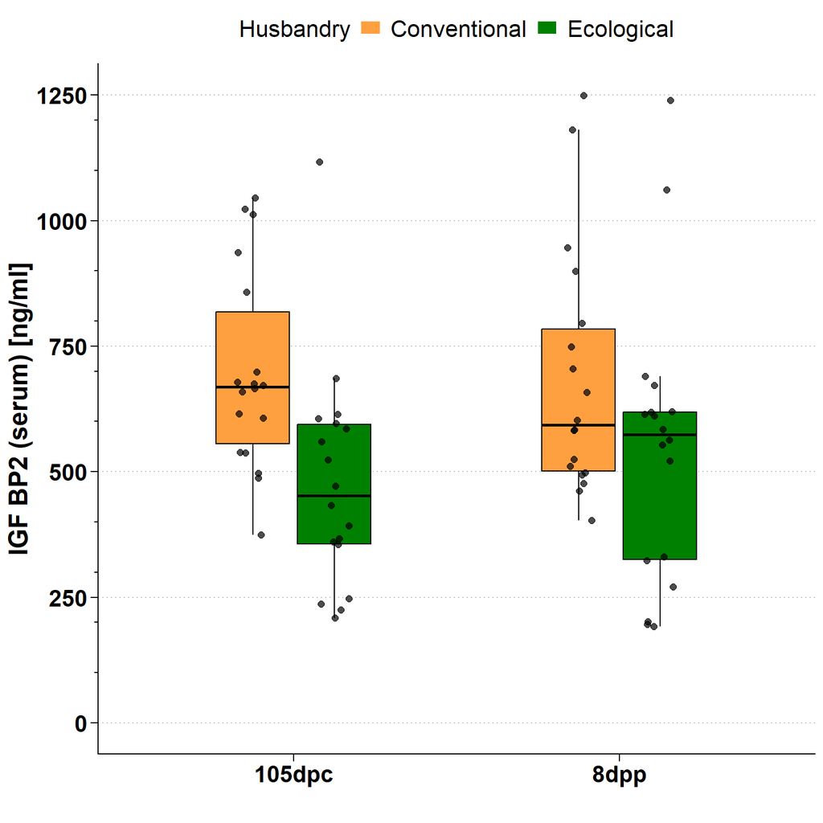

```r
plot.igfbp2
```

# IGFBP3 (serum)

## Model

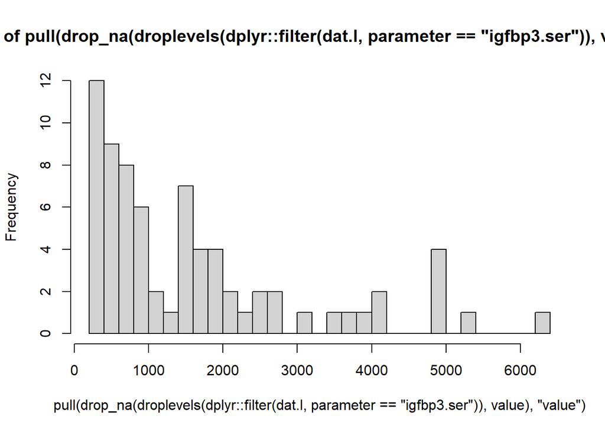

```r
hist(dat.l |>
       dplyr::filter(parameter == "igfbp3.ser") |>
       droplevels() |>
       drop_na(value) |>
       pull("value"),
     breaks = 30)
```

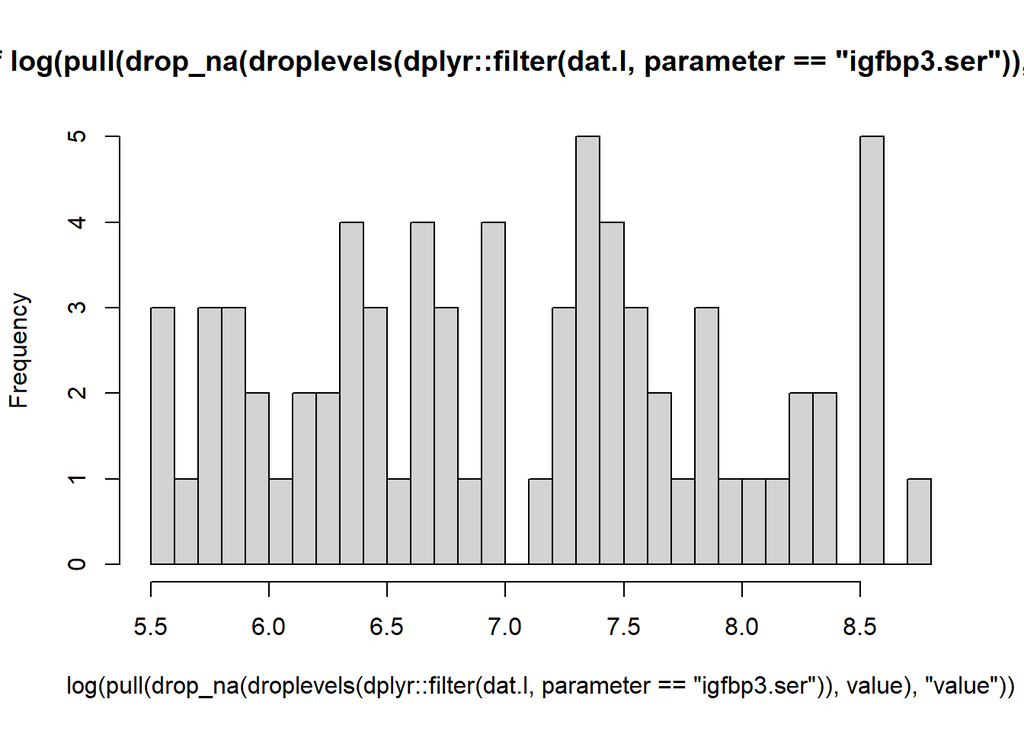

```r
hist(log(dat.l |>
         dplyr::filter(parameter == "igfbp3.ser") |>
         droplevels() |>
         drop_na(value) |>
         pull("value")),
     breaks = 30)
```

Singularity issues if nested structure defined like `(1 | sow/litter.no)`.

```r
mod.igfbp3 <- lmerTest::lmer(log(value) ~
                               husbandry +
                               time +
                               # interaction term
                               husbandry : time +
                               # random intercept for sows and for each litter within sow
                               (1 | sow/litter.no),
                             data    = dat.l |>
                               dplyr::filter(parameter == "igfbp3.ser") |>
                               droplevels() |>
                               drop_na(value),
                             REML    = TRUE,
                             control = contr)
```

```
boundary (singular) fit: see help('isSingular')
```

```r
summary(mod.igfbp3)
```

```
Linear mixed model fit by REML. t-tests use Satterthwaite's method [
lmerModLmerTest]
Formula: log(value) ~ husbandry + time + husbandry:time + (1 | sow/litter.no)
   Data: drop_na(droplevels(dplyr::filter(dat.l, parameter == "igfbp3.ser")),
    value)
Control: contr

REML criterion at convergence: 159.9

Scaled residuals:
     Min       1Q   Median       3Q      Max
-1.78859 -0.50549  0.09757  0.46868  1.52002

Random effects:
 Groups        Name        Variance  Std.Dev.
 litter.no:sow (Intercept) 5.588e-01 7.475e-01
 sow           (Intercept) 6.984e-16 2.643e-08
 Residual                  2.038e-01 4.515e-01
Number of obs: 72, groups:  litter.no:sow, 36; sow, 15

Fixed effects:
                             Estimate Std. Error       df t value Pr(>|t|)
(Intercept)                   6.72944    0.20583 44.24476  32.694  < 2e-16 ***
husbandryecological           0.08475    0.29109 44.24476   0.291  0.77229
time8dpp                      0.53588    0.15048 34.00000   3.561  0.00112 **
husbandryecological:time8dpp -0.03664    0.21282 34.00000  -0.172  0.86434
---
Signif. codes:  0 '***' 0.001 '**' 0.01 '*' 0.05 '.' 0.1 ' ' 1

Correlation of Fixed Effects:
            (Intr) hsbndr tm8dpp
hsbndryclgc -0.707
time8dpp    -0.366  0.258
hsbndrycl:8  0.258 -0.366 -0.707
optimizer (bobyqa) convergence code: 0 (OK)
boundary (singular) fit: see help('isSingular')
```

```r
round(drop1(mod.igfbp3, test = 'Chisq'), 3)
```

```
Single term deletions using Satterthwaite's method:

Model:
log(value) ~ husbandry + time + husbandry:time + (1 | sow/litter.no)
               Sum Sq Mean Sq NumDF DenDF F value Pr(>F)
husbandry:time  0.006   0.006     1    34    0.03  0.864
```

Without significant interactions, choose `type = 2`. With significant interactions, choose `type = 3`.

```r
car::Anova(mod.igfbp3,
           test.statistic = "Chisq",
           type = 2)
```

```
Analysis of Deviance Table (Type II Wald chisquare tests)

Response: log(value)
                 Chisq Df Pr(>Chisq)
husbandry       0.0601  1     0.8063
time           23.6578  1  1.151e-06 ***
husbandry:time  0.0296  1     0.8633
---
Signif. codes:  0 '***' 0.001 '**' 0.01 '*' 0.05 '.' 0.1 ' ' 1
```

```r
car::Anova(mod.igfbp3,
           test.statistic = "F",
           type = 2)
```

```
Analysis of Deviance Table (Type II Wald F tests with Kenward-Roger df)

Response: log(value)
                     F Df Df.res    Pr(>F)
husbandry       0.0583  1 10.995    0.8136
time           23.6578  1 34.000 2.577e-05 ***
husbandry:time  0.0296  1 34.000    0.8643
---
Signif. codes:  0 '***' 0.001 '**' 0.01 '*' 0.05 '.' 0.1 ' ' 1
```

## Model diagnostics

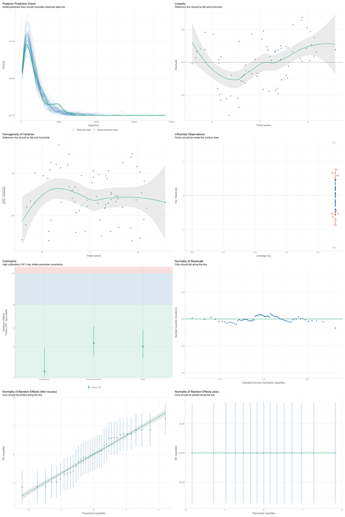

```r
performance::check_model(mod.igfbp3)
```

## Emmeans & Effect sizes

### Husbandry

Emmeans:

```r
emm <- emmeans(mod.igfbp3,
        pairwise ~ husbandry,
        data    = dat.l |>
          dplyr::filter(parameter == "igfbp3.ser") |>
          droplevels() |>
          drop_na(value),
        adjust  = "tukey",
        lmer.df = "satterthwaite",
        type    = "response")
```

```
NOTE: Results may be misleading due to involvement in interactions
```

```r
emm
```

```
$emmeans
 husbandry    response  SE df lower.CL upper.CL
 conventional     1094 210 34      741     1614
 ecological       1169 224 34      792     1725

Results are averaged over the levels of: time
Degrees-of-freedom method: satterthwaite
Confidence level used: 0.95
Intervals are back-transformed from the log scale

$contrasts
 contrast                  ratio    SE df null t.ratio p.value
 conventional / ecological 0.936 0.254 34    1  -0.245  0.8078

Results are averaged over the levels of: time
Degrees-of-freedom method: satterthwaite
Tests are performed on the log scale
```

Effect sizes:

```r
eff_size(emm,
         sigma = sigma(mod.igfbp3),
         edf = df.residual(mod.igfbp3))
```

```
Since 'object' is a list, we are using the contrasts already present.
```

```
 contrast                    estimate  SE df lower.CL upper.CL
 (conventional - ecological)   -0.147 0.6 34    -1.37     1.07

Results are averaged over the levels of: time
sigma used for effect sizes: 0.4515
Degrees-of-freedom method: inherited from satterthwaite when re-gridding
Confidence level used: 0.95
```

### Time point

Emmeans:

```r
emm <- emmeans(mod.igfbp3,
        pairwise ~ time,
        data    = dat.l |>
          dplyr::filter(parameter == "igfbp3.ser") |>
          droplevels() |>
          drop_na(value),
        adjust  = "tukey",
        lmer.df = "satterthwaite",
        type    = "response")
```

```
NOTE: Results may be misleading due to involvement in interactions
```

```r
emm
```

```
$emmeans
 time   response  SE   df lower.CL upper.CL
 105dpc      873 127 44.2      651     1170
 8dpp       1465 213 44.2     1092     1964

Results are averaged over the levels of: husbandry
Degrees-of-freedom method: satterthwaite
Confidence level used: 0.95
Intervals are back-transformed from the log scale

$contrasts
 contrast      ratio     SE df null t.ratio p.value
 105dpc / 8dpp 0.596 0.0634 34    1  -4.864  <.0001

Results are averaged over the levels of: husbandry
Degrees-of-freedom method: satterthwaite
Tests are performed on the log scale
```

Effect sizes:

```r
eff_size(emm,
         sigma = sigma(mod.igfbp3),
         edf = df.residual(mod.igfbp3))
```

```
Since 'object' is a list, we are using the contrasts already present.
```

```
 contrast        estimate    SE df lower.CL upper.CL
 (105dpc - 8dpp)    -1.15 0.256 34    -1.67   -0.626

Results are averaged over the levels of: husbandry
sigma used for effect sizes: 0.4515
Degrees-of-freedom method: inherited from satterthwaite when re-gridding
Confidence level used: 0.95
```

### Husbandry:Time point

Emmeans:

```r
emm.igfbp3_ht <- emmeans(mod.igfbp3,
                         pairwise ~ husbandry|time,
                         data    = dat.l |>
                           dplyr::filter(parameter == "igfbp3.ser") |>
                           droplevels() |>
                           drop_na(value),
                         adjust  = "tukey",
                         lmer.df = "satterthwaite",
                         type    = "response")

emm.igfbp3_ht
```

```
$emmeans
time = 105dpc:
 husbandry    response  SE   df lower.CL upper.CL
 conventional      837 172 44.2      553     1267
 ecological        911 187 44.2      602     1379

time = 8dpp:
 husbandry    response  SE   df lower.CL upper.CL
 conventional     1430 294 44.2      944     2165
 ecological       1500 309 44.2      991     2271

Degrees-of-freedom method: satterthwaite
Confidence level used: 0.95
Intervals are back-transformed from the log scale

$contrasts
time = 105dpc:
 contrast                  ratio    SE   df null t.ratio p.value
 conventional / ecological 0.919 0.267 44.2    1  -0.291  0.7723

time = 8dpp:
 contrast                  ratio    SE   df null t.ratio p.value
 conventional / ecological 0.953 0.277 44.2    1  -0.165  0.8695

Degrees-of-freedom method: satterthwaite
Tests are performed on the log scale
```

Effect sizes:

```r
eff_size(emm.igfbp3_ht,
         sigma = sigma(mod.igfbp3),
         edf = df.residual(mod.igfbp3))
```

```
Since 'object' is a list, we are using the contrasts already present.
```

```
time = 105dpc:
 contrast                    estimate    SE   df lower.CL upper.CL
 (conventional - ecological)   -0.188 0.645 44.2    -1.49     1.11

time = 8dpp:
 contrast                    estimate    SE   df lower.CL upper.CL
 (conventional - ecological)   -0.107 0.645 44.2    -1.41     1.19

sigma used for effect sizes: 0.4515
Degrees-of-freedom method: inherited from satterthwaite when re-gridding
Confidence level used: 0.95
```

### Time point:Husbandry

Emmeans:

```r
emm.igfbp3_th <- emmeans(mod.igfbp3,
                         pairwise ~ time|husbandry,
                         data    = dat.l |>
                           dplyr::filter(parameter == "igfbp3.ser") |>
                           droplevels() |>
                           drop_na(value),
                         adjust  = "tukey",
                         lmer.df = "satterthwaite",
                         type    = "response")

emm.igfbp3_th
```

```
$emmeans
husbandry = conventional:
 time   response  SE   df lower.CL upper.CL
 105dpc      837 172 44.2      553     1267
 8dpp       1430 294 44.2      944     2165

husbandry = ecological:
 time   response  SE   df lower.CL upper.CL
 105dpc      911 187 44.2      602     1379
 8dpp       1500 309 44.2      991     2271

Degrees-of-freedom method: satterthwaite
Confidence level used: 0.95
Intervals are back-transformed from the log scale

$contrasts
husbandry = conventional:
 contrast      ratio     SE df null t.ratio p.value
 105dpc / 8dpp 0.585 0.0881 34    1  -3.561  0.0011

husbandry = ecological:
 contrast      ratio     SE df null t.ratio p.value
 105dpc / 8dpp 0.607 0.0913 34    1  -3.318  0.0022

Degrees-of-freedom method: satterthwaite
Tests are performed on the log scale
```

Effect sizes:

```r
eff_size(emm.igfbp3_th,
         sigma = sigma(mod.igfbp3),
         edf = df.residual(mod.igfbp3))
```

```
Since 'object' is a list, we are using the contrasts already present.
```

```
husbandry = conventional:
 contrast        estimate    SE df lower.CL upper.CL
 (105dpc - 8dpp)    -1.19 0.349 34    -1.90   -0.477

husbandry = ecological:
 contrast        estimate    SE df lower.CL upper.CL
 (105dpc - 8dpp)    -1.11 0.347 34    -1.81   -0.400

sigma used for effect sizes: 0.4515
Degrees-of-freedom method: inherited from satterthwaite when re-gridding
Confidence level used: 0.95
```

## Plot

```r
plot.igfbp3 <- dat.l  |>
  dplyr::filter(parameter == "igfbp3.ser") |>
  droplevels() |>
  drop_na(value) |>
  # plot
  mutate(jit = jitter(as.numeric(time), 0.3)) |>
  ggplot(aes(y   = value)) +
  geom_boxplot(aes(x   = time,
                   fill = husbandry),
               col = "black",
               outlier.shape = NA, width = 0.5) +
  geom_jitter(aes(x   = time,
                  fill = husbandry),
              col = "black",
              position = position_jitterdodge(jitter.width  = 0.15,
                                              dodge.width   = 0.5),
              size = 2, alpha = 0.7,
              show.legend = FALSE) +
  scale_fill_manual(labels = c("Conventional",
                               "Ecological"),
                    values = c("#FFA040", "#008000")) +
  scale_y_continuous(lim = c(0, 6500),
                     breaks = seq(0, 6500, 2000),
                     minor_breaks = seq(0, 6500, by = 200) ) +
  scale_x_discrete(labels= c("105dpc", "8dpp")) +
  labs(x = "",
       y = "IGF BP3 (serum) [ng/ml]",
       fill = "Husbandry") +
  my_theme +
  theme(legend.position = "top") +
  guides(y = guide_axis(minor.ticks = TRUE),
         fill = guide_legend(override.aes = list(linetype = 0, size  = 5)))
```

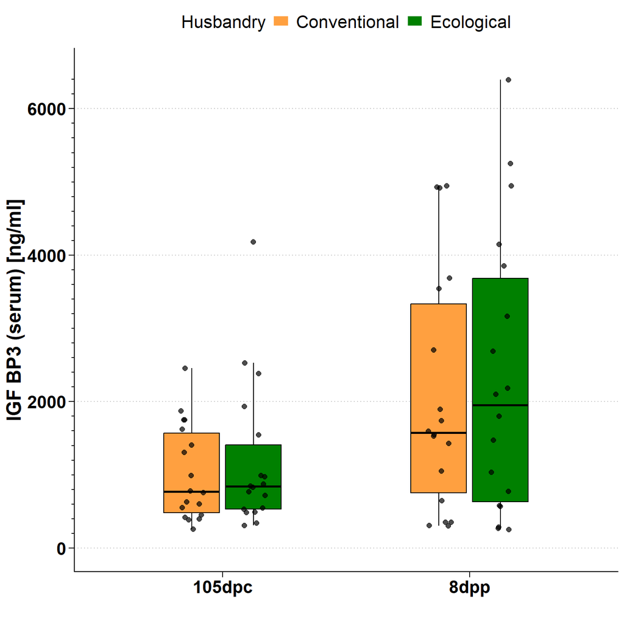

```r
plot.igfbp3
```